DAND Term 2, Project 3:

# Wrangle and Analyse Data: WeRateDogs Twitter activity

## 1 - Introduction

WeRateDogs (https://twitter.com/dog_rates) is a Twitter account that rates people's dogs with a humorous comment about the dog. The goal of this project is to wrangle WeRateDogs Twitter data to create interesting and trustworthy analyses and visualizations. This requires the prior gathering assessing and cleaning of the data.

```python
#load Python libraries
import pandas as pd
import numpy as np
import requests
import tweepy
import json
import matplotlib.pyplot as plt
import seaborn as sns
from scipy import stats
```

```python
#set up matplotlib to work interactively
%matplotlib inline
sns.set()           # switch on seaborn defaults
```

## 2 - Gathering

There different pieces of data are gathered for the project as described in the Project Details page :

### WeRateDogs Twitter archive

from the course's project description :

*The WeRateDogs Twitter archive. I am giving this file to you, so imagine it as a file on hand. Download this file manually by clicking the following link: twitter_archive_enhanced.csv*

```python
#this file was downloded and saved in the same folder as the Jupyter notebook file
# it can simply be read into a dataframe
df_archive = pd.read_csv('twitter-archive-enhanced.csv')
```

```python
#initial check to see what the dataframe looks like
df_archive.head(3)
```

|  | tweet_id | in_reply_to_status_id | in_reply_to_user_id | timestamp | source | text | retweeted_status_id | retweeted_status_user_id | retweeted_status_timestamp | expanded_urls | rating_numerator | rating_denominator | name | doggo | floofer | pupper | puppo |
| --- | --- | --- | --- | --- | --- | --- | --- | --- | --- | --- | --- | --- | --- | --- | --- | --- | --- |
| 0 | 892420643555336193 | NaN | NaN | 2017-08-01 16:23:56 +0000 | <a href="http://twitter.com/download/iphone" r... | This is Phineas. He's a mystical boy. Only eve... | NaN | NaN | NaN | https://twitter.com/dog_rates/status/892420643... | 13 | 10 | Phineas | None | None | None | None |
| 1 | 892177421306343426 | NaN | NaN | 2017-08-01 00:17:27 +0000 | <a href="http://twitter.com/download/iphone" r... | This is Tilly. She's just checking pup on you.... | NaN | NaN | NaN | https://twitter.com/dog_rates/status/892177421... | 13 | 10 | Tilly | None | None | None | None |
| 2 | 891815181378084864 | NaN | NaN | 2017-07-31 00:18:03 +0000 | <a href="http://twitter.com/download/iphone" r... | This is Archie. He is a rare Norwegian Pouncin... | NaN | NaN | NaN | https://twitter.com/dog_rates/status/891815181... | 12 | 10 | Archie | None | None | None | None |

### Tweet image predictions

from the course's project description :

*The tweet image predictions, i.e., what breed of dog (or other object, animal, etc.) is present in each tweet according to a neural network. This file (image_predictions.tsv) is hosted on Udacity's servers and should be downloaded programmatically using the Requests library and the following URL: https://d17h27t6h515a5.cloudfront.net/topher/2017/August/599fd2ad_image-predictions/image-predictions.tsv*

```python
#load .tsv into working memory using a method from the requests library
df_predictions  = requests.get('https://d17h27t6h515a5.cloudfront.net/topher/2017/August/599fd2ad_image-predictions/image-predictions.tsv')

#store in working direcory
with open('image-predictions.tsv',mode='wb') as file:
              file.write(df_predictions.content)
```

```python
#read .tsv into dataframe, specifying the tab separator
df_predictions = pd.read_csv('image-predictions.tsv',sep="\t")
```

```python
#initial check what the dataframe looks like
df_predictions.head(3)
```

|  | tweet_id | jpg_url | img_num | p1 | p1_conf | p1_dog | p2 | p2_conf | p2_dog | p3 | p3_conf | p3_dog |
| --- | --- | --- | --- | --- | --- | --- | --- | --- | --- | --- | --- | --- |
| 0 | 666020888022790149 | https://pbs.twimg.com/media/CT4udn0WwAA0aMy.jpg | 1 | Welsh_springer_spaniel | 0.465074 | True | collie | 0.156665 | True | Shetland_sheepdog | 0.061428 | True |
| 1 | 666029285002620928 | https://pbs.twimg.com/media/CT42GRgUYAA5iDo.jpg | 1 | redbone | 0.506826 | True | miniature_pinscher | 0.074192 | True | Rhodesian_ridgeback | 0.072010 | True |
| 2 | 666033412701032449 | https://pbs.twimg.com/media/CT4521TWwAEvMyu.jpg | 1 | German_shepherd | 0.596461 | True | malinois | 0.138584 | True | bloodhound | 0.116197 | True |

### Additional gathering from Twitter API using Tweepy library

from the course's project description :

*Each tweet's retweet count and favorite ("like") count at minimum, and any additional data you find interesting. Using the tweet IDs in the WeRateDogs Twitter archive, query the Twitter API for each tweet's JSON data using Python's Tweepy library and store each tweet's entire set of JSON data in a file called tweet_json.txt file. Each tweet's JSON data should be written to its own line. Then read this .txt file line by line into a pandas DataFrame with (at minimum) tweet ID, retweet count, and favorite count.* *Note: do not include your Twitter API keys, secrets, and tokens in your project submission.*

```python
#I obtained a Twitter dev account and the relevant API keys, secrets
#and tokens are below :

consumer_key = '########################################################'
consumer_secret = '########################################################'
access_token = '########################################################'
access_secret = '########################################################'

auth = tweepy.OAuthHandler(consumer_key, consumer_secret)
auth.set_access_token(access_token, access_secret)

#api = tweepy.API(auth)
#ensure appropriate rate_limit as described here: https://stackoverflow.com/a/44586034
api = tweepy.API(auth, wait_on_rate_limit=True, wait_on_rate_limit_notify=True)
```

```python
#function to look up list of tweets, adapted from https://stackoverflow.com/a/44586034
def lookup_tweets(tweet_IDs):
    '''
    Returns list of tweets as generated by Twitter API
    Parameter: Tweet IDs, either as a list of integers, or
    column of a Pandas dataframe ;
    handles 100 tweet limit, uses api.statuses_lookup()
    '''
    if isinstance(tweet_IDs, pd.Series): #https://stackoverflow.com/a/18117744
        tweet_IDs = tweet_IDs.tolist() #convert pandas df column to list

    full_tweets = [] #initialise list for list of tweets
    tweet_count = len(tweet_IDs)
    try:
        for i in range((tweet_count // 100) + 1): #handle 100 tweet limit
                        # Catch the last group if it is less than 100 tweets
            end_loc = min((i + 1) * 100, tweet_count)
            print(i)    #get feedback during downloading
            print("range {} to {}".format(i*100,end_loc))
            full_tweets.extend(
                api.statuses_lookup(tweet_IDs[i * 100:end_loc])
            )
        return full_tweets
    except tweepy.TweepError:
        print("Something went wrong, quitting...")
```

```python
# The aim is to use the Tweet IDs from WeRateDogs Twitter archive to gather
# additional information using the lookup_tweets() function
# with the tweet_id column from df_archive
results = lookup_tweets(df_archive.tweet_id)
```

```
0
range 0 to 100
1
range 100 to 200
2
range 200 to 300
3
range 300 to 400
4
range 400 to 500
5
range 500 to 600
6
range 600 to 700
7
range 700 to 800
8
range 800 to 900
9
range 900 to 1000
10
range 1000 to 1100
11
range 1100 to 1200
12
range 1200 to 1300
13
range 1300 to 1400
14
range 1400 to 1500
15
range 1500 to 1600
16
range 1600 to 1700
17
range 1700 to 1800
18
range 1800 to 1900
19
range 1900 to 2000
20
range 2000 to 2100
21
range 2100 to 2200
22
range 2200 to 2300
23
range 2300 to 2356
```

```python
#Next the tweets will be stored in a text file with one line per tweet
#using the _json property which contains JSON serializable response data
#as the tweepy status object itself is not JSON serializable https://stackoverflow.com/a/27901076
for tweet in results:
    with open('tweet_json.txt', 'a', encoding='utf8') as file: #append to text file
        json.dump(tweet._json,file)
            #json.dump()) as described in https://stackabuse.com/reading-and-writing-json-to-a-file-in-python/
        file.write("\n") #add newline character
```

The structure of JSON tweet objects is explained in https://developer.twitter.com/en/docs/tweets/data-dictionary/overview/intro-to-tweet-json.html

Tweet objects contain information such as the tweet "id", "text", "user", as well as the retweet_count favorite_count - the latter two are specified in the projection description. I will also use the tweet id (so that it can be matched with the archive) as well as the user name.

JSON of tweets which are retweets (i.e. simply re-posting an existing tweet potentially authored by another user, as is but creating a new tweet) or quote tweets (i.e. reposting an existing tweet with additional tweet text) contain additional tweet objects : a "retweeted_status" object or a "quoted_status" object, respectively. The "retweeted_status" and "quoted_status" objects also contain information such as "id", "text", "user" of the the tweet being retweeted/quoted. They are simply absent from tweet obects that aren't retweeted/quoted. In order to be able to easily distinguish between original tweets by WeRateDogs, I will add columns for whether a tweet is a retweet, a quote tweet, as well as the author of the original tweets being retweeted/quoted. Similarly I will add information about whether a tweet is a reply to another tweet, again to be able to easily distinguish between original tweets by WeRateDogs and tweets that are part of an ongoing conversation.

```python
#The json file with the tweets will be read in and processed to build a
#dataframe with IDs, retweet count and favourite count
#also check if a tweet is a retweet, and if it is a reply


additional = [] #initialise list that will hold dicitionaries
with open('tweet_json.txt','r', encoding='utf8') as file:
    for line in file:
        tweet=json.loads(line)

        #get retweet status, user if they exist
        try:
            retweet_user=tweet['retweeted_status']['user']['name']
            is_retweet = True
        except:
            retweet_user = None
            is_retweet = False

            #get quote status, user if they exist
        try:
            quote_user=tweet['quoted_status']['user']['name']
            is_quote = True
        except:
            quote_user = None
            is_quote = False



        additional.append({'tweet_id': tweet['id'],
                           'user_name':tweet['user']['name'],
                          'retweet_count': tweet['retweet_count'],
                           'favorite_count' : tweet['favorite_count'],
                           #'is_retweet' : 'retweeted_status' in tweet,
                                 #check if it's a retweet, adapted from https://stackoverflow.com/a/18937252
                           'is_retweet' : is_retweet,
                           'retweet_user' : retweet_user,
                           'is_quote' : is_quote,
                           'quote_user': quote_user,
                           'is_reply' : tweet['in_reply_to_status_id'] is not None
                                 #check if it's a reply, adapted from https://stackoverflow.com/a/49469052
                          })
       # break

df_additional=pd.DataFrame(additional, columns=['tweet_id','user_name','retweet_count','favorite_count','is_retweet','retweet_user','is_quote','quote_user','is_reply'])
```

```python
#initial check of new dataframe
df_additional.head(3)
```

|  | tweet_id | user_name | retweet_count | favorite_count | is_retweet | retweet_user | is_quote | quote_user | is_reply |
| --- | --- | --- | --- | --- | --- | --- | --- | --- | --- |
| 0 | 876484053909872640 | WeRateDogs™ | 2327 | 18309 | False | None | False | None | False |
| 1 | 886366144734445568 | WeRateDogs™ | 3100 | 20637 | False | None | False | None | False |
| 2 | 877611172832227328 | WeRateDogs™ | 78 | 0 | True | Rachel Baker | False | None | False |

```python
df_additional.shape
```

```
(2339, 9)
```

## 3 - Assess

Data quality needs to be assessed in the context of the questions that analysis of a data set is meant to answer. Before starting the assessment, it's helpful to be aware of what those questions might be. For the present data, questions might include:

- is the idiosyncratic rating system meaningful?
- which dogs are the most popular?
- how is the popularity of tweets from this Twitter account developing over time?

### Assessing additional data gathered using Tweepy (df_additional)

```python
df_additional.info()
```

```
<class 'pandas.core.frame.DataFrame'>
RangeIndex: 2339 entries, 0 to 2338
Data columns (total 9 columns):
tweet_id          2339 non-null int64
user_name         2339 non-null object
retweet_count     2339 non-null int64
favorite_count    2339 non-null int64
is_retweet        2339 non-null bool
retweet_user      167 non-null object
is_quote          2339 non-null bool
quote_user        24 non-null object
is_reply          2339 non-null bool
dtypes: bool(3), int64(3), object(3)
memory usage: 116.6+ KB
```

Data types look OK. None values for retweet_user, quote_user are accurate rather than missing values because these tweets are not retweets/quote tweets. tweet_id could also be a string rather than integer, but integer may be more efficient here.

```python
#visual assessment of the dataframe in Pandas - also done in separate spreadsheet software

df_additional
```

|  | tweet_id | user_name | retweet_count | favorite_count | is_retweet | retweet_user | is_quote | quote_user | is_reply |
| --- | --- | --- | --- | --- | --- | --- | --- | --- | --- |
| 0 | 876484053909872640 | WeRateDogs™ | 2327 | 18309 | False | None | False | None | False |
| 1 | 886366144734445568 | WeRateDogs™ | 3100 | 20637 | False | None | False | None | False |
| 2 | 877611172832227328 | WeRateDogs™ | 78 | 0 | True | Rachel Baker | False | None | False |
| 3 | 888078434458587136 | WeRateDogs™ | 3378 | 21193 | False | None | False | None | False |
| 4 | 891689557279858688 | WeRateDogs™ | 8373 | 41028 | False | None | False | None | False |
| 5 | 879492040517615616 | WeRateDogs™ | 3088 | 22844 | False | None | False | None | False |
| 6 | 878604707211726852 | WeRateDogs™ | 6996 | 29473 | False | None | True | BBC News (World) | False |
| 7 | 879674319642796034 | WeRateDogs™ | 10 | 301 | False | None | False | None | True |
| 8 | 884876753390489601 | WeRateDogs™ | 5444 | 27185 | False | None | False | None | False |
| 9 | 882992080364220416 | WeRateDogs™ | 3804 | 23328 | False | None | False | None | False |
| 10 | 876120275196170240 | WeRateDogs™ | 4561 | 27275 | False | None | False | None | False |
| 11 | 889880896479866881 | WeRateDogs™ | 4820 | 27085 | False | None | False | None | False |
| 12 | 885518971528720385 | WeRateDogs™ | 3634 | 19915 | False | None | False | None | False |
| 13 | 879862464715927552 | WeRateDogs™ | 3394 | 21785 | False | None | False | None | False |
| 14 | 877556246731214848 | WeRateDogs™ | 3696 | 22174 | False | None | False | None | False |
| 15 | 890971913173991426 | WeRateDogs™ | 1989 | 11530 | False | None | False | None | False |
| 16 | 890006608113172480 | WeRateDogs™ | 7097 | 29888 | False | None | False | None | False |
| 17 | 873580283840344065 | WeRateDogs™ | 3847 | 23674 | False | None | False | None | False |
| 18 | 880935762899988482 | WeRateDogs™ | 2704 | 16616 | False | None | False | None | False |
| 19 | 891815181378084864 | WeRateDogs™ | 4020 | 24391 | False | None | False | None | False |
| 20 | 877201837425926144 | WeRateDogs™ | 5433 | 26475 | False | None | False | None | False |
| 21 | 886267009285017600 | WeRateDogs™ | 4 | 116 | False | None | False | None | True |
| 22 | 873337748698140672 | WeRateDogs™ | 1549 | 0 | True | WeRateDogs™ | False | None | False |
| 23 | 875747767867523072 | WeRateDogs™ | 4178 | 24593 | False | None | False | None | False |
| 24 | 889278841981685760 | WeRateDogs™ | 5203 | 24588 | False | None | False | None | False |
| 25 | 879415818425184262 | WeRateDogs™ | 43040 | 103165 | False | None | False | None | False |
| 26 | 882268110199369728 | WeRateDogs™ | 11241 | 43774 | False | None | False | None | False |
| 27 | 880465832366813184 | WeRateDogs™ | 6098 | 27800 | False | None | False | None | False |
| 28 | 887101392804085760 | WeRateDogs™ | 5775 | 29787 | False | None | False | None | False |
| 29 | 884162670584377345 | WeRateDogs™ | 2890 | 19836 | False | None | False | None | False |
| ... | ... | ... | ... | ... | ... | ... | ... | ... | ... |
| 2309 | 666020888022790149 | WeRateDogs™ | 497 | 2519 | False | None | False | None | False |
| 2310 | 666421158376562688 | WeRateDogs™ | 111 | 310 | False | None | False | None | False |
| 2311 | 666983947667116034 | WeRateDogs™ | 979 | 2528 | False | None | False | None | False |
| 2312 | 666063827256086533 | WeRateDogs™ | 213 | 463 | False | None | False | None | False |
| 2313 | 666447344410484738 | WeRateDogs™ | 19 | 102 | False | None | False | None | False |
| 2314 | 666691418707132416 | WeRateDogs™ | 47 | 185 | False | None | False | None | False |
| 2315 | 666337882303524864 | WeRateDogs™ | 88 | 192 | False | None | False | None | False |
| 2316 | 666273097616637952 | WeRateDogs™ | 76 | 170 | False | None | False | None | False |
| 2317 | 667044094246576128 | WeRateDogs™ | 50 | 182 | False | None | False | None | False |
| 2318 | 666411507551481857 | WeRateDogs™ | 321 | 432 | False | None | False | None | False |
| 2319 | 666786068205871104 | WeRateDogs™ | 484 | 750 | False | None | False | None | False |
| 2320 | 666428276349472768 | WeRateDogs™ | 81 | 162 | False | None | False | None | False |
| 2321 | 666353288456101888 | WeRateDogs™ | 71 | 214 | False | None | False | None | False |
| 2322 | 666826780179869698 | WeRateDogs™ | 97 | 251 | False | None | False | None | False |
| 2323 | 666804364988780544 | WeRateDogs™ | 92 | 236 | False | None | False | None | False |
| 2324 | 666817836334096384 | WeRateDogs™ | 249 | 512 | False | None | False | None | False |
| 2325 | 666396247373291520 | WeRateDogs™ | 83 | 161 | False | None | False | None | False |
| 2326 | 666644823164719104 | WeRateDogs™ | 79 | 228 | False | None | False | None | False |
| 2327 | 666649482315059201 | WeRateDogs™ | 617 | 1105 | False | None | False | None | False |
| 2328 | 666055525042405380 | WeRateDogs™ | 235 | 427 | False | None | False | None | False |
| 2329 | 666051853826850816 | WeRateDogs™ | 828 | 1193 | False | None | False | None | False |
| 2330 | 666094000022159362 | WeRateDogs™ | 72 | 160 | False | None | False | None | False |
| 2331 | 666430724426358785 | WeRateDogs™ | 194 | 311 | False | None | False | None | False |
| 2332 | 666287406224695296 | WeRateDogs™ | 63 | 142 | False | None | False | None | False |
| 2333 | 666437273139982337 | WeRateDogs™ | 47 | 122 | False | None | False | None | False |
| 2334 | 666099513787052032 | WeRateDogs™ | 66 | 150 | False | None | False | None | False |
| 2335 | 666268910803644416 | WeRateDogs™ | 35 | 100 | False | None | False | None | False |
| 2336 | 666362758909284353 | WeRateDogs™ | 559 | 756 | False | None | False | None | False |
| 2337 | 666835007768551424 | WeRateDogs™ | 80 | 211 | False | None | False | None | False |
| 2338 | 666104133288665088 | WeRateDogs™ | 6355 | 13987 | False | None | False | None | False |

2339 rows × 9 columns

```python
df_additional.describe()
```

|  | tweet_id | retweet_count | favorite_count |
| --- | --- | --- | --- |
| count | 2.339000e+03 | 2339.000000 | 2339.000000 |
| mean | 7.421620e+17 | 2897.746045 | 7884.252672 |
| std | 6.828729e+16 | 4886.564270 | 12218.674683 |
| min | 6.660209e+17 | 1.000000 | 0.000000 |
| 25% | 6.783378e+17 | 582.500000 | 1365.500000 |
| 50% | 7.186133e+17 | 1353.000000 | 3430.000000 |
| 75% | 7.986907e+17 | 3377.500000 | 9653.500000 |
| max | 8.924206e+17 | 82838.000000 | 162741.000000 |

retweet_count and favorite_count of 0 seem low compared to their respective median values- what are these?

```python
df_additional[df_additional.favorite_count==0].head(10)
```

|  | tweet_id | user_name | retweet_count | favorite_count | is_retweet | retweet_user | is_quote | quote_user | is_reply |
| --- | --- | --- | --- | --- | --- | --- | --- | --- | --- |
| 2 | 877611172832227328 | WeRateDogs™ | 78 | 0 | True | Rachel Baker | False | None | False |
| 22 | 873337748698140672 | WeRateDogs™ | 1549 | 0 | True | WeRateDogs™ | False | None | False |
| 37 | 874434818259525634 | WeRateDogs™ | 14349 | 0 | True | WeRateDogs™ | False | None | False |
| 50 | 879130579576475649 | WeRateDogs™ | 6620 | 0 | True | WeRateDogs™ | False | None | False |
| 53 | 878404777348136964 | WeRateDogs™ | 1250 | 0 | True | WeRateDogs™ | False | None | False |
| 54 | 886054160059072513 | WeRateDogs™ | 105 | 0 | True | Ramón Laureano’s Arm 💪🏽 | False | None | False |
| 60 | 885311592912609280 | WeRateDogs™ | 17974 | 0 | True | WeRateDogs™ | False | None | False |
| 85 | 878316110768087041 | WeRateDogs™ | 6464 | 0 | True | WeRateDogs™ | False | None | False |
| 98 | 858860390427611136 | WeRateDogs™ | 8229 | 0 | True | WeRateDogs™ | False | None | False |
| 99 | 868639477480148993 | WeRateDogs™ | 2069 | 0 | True | WeRateDogs™ | False | None | False |

```python
df_additional[df_additional.favorite_count==0].is_retweet.value_counts()
```

```
True    167
Name: is_retweet, dtype: int64
```

Low **favorite_count** values are seen on retweets - because favourites are added to the original tweet rather than the retweet. This is true whether the retweet is of another user's tweet or a tweet by WeRateDogs. These low favorite_count values are not reflective of a data quality issue - but are important to understand the data.

```python
df_additional[df_additional.retweet_count<10]
```

|  | tweet_id | user_name | retweet_count | favorite_count | is_retweet | retweet_user | is_quote | quote_user | is_reply |
| --- | --- | --- | --- | --- | --- | --- | --- | --- | --- |
| 21 | 886267009285017600 | WeRateDogs™ | 4 | 116 | False | None | False | None | True |
| 38 | 881633300179243008 | WeRateDogs™ | 7 | 124 | False | None | False | None | True |
| 187 | 870726314365509632 | WeRateDogs™ | 3 | 117 | False | None | False | None | True |
| 232 | 840698636975636481 | WeRateDogs™ | 2 | 183 | False | None | False | None | True |
| 252 | 838085839343206401 | WeRateDogs™ | 1 | 147 | False | None | False | None | True |
| 293 | 832088576586297345 | WeRateDogs™ | 2 | 69 | False | None | False | None | True |
| 1030 | 738891149612572673 | WeRateDogs™ | 6 | 112 | False | None | False | None | True |
| 1266 | 707983188426153984 | WeRateDogs™ | 2 | 51 | False | None | False | None | True |

Low **retweet_count** values are seen on tweets which are replies and presumably often of lesser interest in isolation therfore generally not worth retweeting. Again: not reflective of a data quality issue - but are important to understand the data.

```python
df_additional[df_additional.favorite_count==0].head(10)
```

|  | tweet_id | user_name | retweet_count | favorite_count | is_retweet | retweet_user | is_quote | quote_user | is_reply |
| --- | --- | --- | --- | --- | --- | --- | --- | --- | --- |
| 2 | 877611172832227328 | WeRateDogs™ | 78 | 0 | True | Rachel Baker | False | None | False |
| 22 | 873337748698140672 | WeRateDogs™ | 1549 | 0 | True | WeRateDogs™ | False | None | False |
| 37 | 874434818259525634 | WeRateDogs™ | 14349 | 0 | True | WeRateDogs™ | False | None | False |
| 50 | 879130579576475649 | WeRateDogs™ | 6620 | 0 | True | WeRateDogs™ | False | None | False |
| 53 | 878404777348136964 | WeRateDogs™ | 1250 | 0 | True | WeRateDogs™ | False | None | False |
| 54 | 886054160059072513 | WeRateDogs™ | 105 | 0 | True | Ramón Laureano’s Arm 💪🏽 | False | None | False |
| 60 | 885311592912609280 | WeRateDogs™ | 17974 | 0 | True | WeRateDogs™ | False | None | False |
| 85 | 878316110768087041 | WeRateDogs™ | 6464 | 0 | True | WeRateDogs™ | False | None | False |
| 98 | 858860390427611136 | WeRateDogs™ | 8229 | 0 | True | WeRateDogs™ | False | None | False |
| 99 | 868639477480148993 | WeRateDogs™ | 2069 | 0 | True | WeRateDogs™ | False | None | False |

```python
df_additional.retweet_user.value_counts()
```

```
WeRateDogs™                           144
We Rate Dog Ratings                     2
Jon 🇬🇧                                  1
Rachel Baker                            1
tally                                   1
Ramón Laureano’s Arm 💪🏽                 1
Rachael                                 1
Jeannette                               1
Patreon                                 1
♪{•.•}* • banditø 8/3/19                1
Ellen M                                 1
Jenna Marbles                           1
Lin-Manuel Miranda                      1
Kiba                                    1
Eddie                                   1
Twitter                                 1
Kate Gray                               1
katie                                   1
Allison Schafer                         1
Gia 👩🏼‍🍳                                1
That wasn't very cash money of you      1
Emilie Shepherd                         1
Aaron Chewning                          1
Name: retweet_user, dtype: int64
```

```python
df_additional.quote_user.value_counts()
```

```
NBC News                   1
Shomari Stone              1
Codeine Bryant             1
Yahoo News                 1
Animal Cognition           1
Tower Hamlets Police       1
Bellevue, WA Police        1
ABC News                   1
Thug on a thot tin roof    1
Mark Halperin              1
WSAZ NewsChannel 3         1
FOX Deportes               1
Badlands Nat'l Park        1
NBC Sports Capitals        1
KTLA                       1
Micah Grimes               1
StickerGrub                1
WGN TV News                1
Deadspin                   1
Kai Johnson                1
BBC News (World)           1
The Telegraph              1
KING 5 News                1
CHP San Francisco          1
Name: quote_user, dtype: int64
```

WeRateDogs doesn't quote-tweet their own tweets, but commonly retweets their own tweets - this is a popular way for tweeters to boost their recent posts.

No major data quality issues stand out with the additional tweet data in df_additional. Data completeness and tidiness is assessed below.

### Assessing the WeRateDogs Twitter archive (df_archive)

```python
#visual assessment of the dataframe in Pandas - also done in separate spreadsheet software
df_archive
```

|  | tweet_id | in_reply_to_status_id | in_reply_to_user_id | timestamp | source | text | retweeted_status_id | retweeted_status_user_id | retweeted_status_timestamp | expanded_urls | rating_numerator | rating_denominator | name | doggo | floofer | pupper | puppo |
| --- | --- | --- | --- | --- | --- | --- | --- | --- | --- | --- | --- | --- | --- | --- | --- | --- | --- |
| 0 | 892420643555336193 | NaN | NaN | 2017-08-01 16:23:56 +0000 | <a href="http://twitter.com/download/iphone" r... | This is Phineas. He's a mystical boy. Only eve... | NaN | NaN | NaN | https://twitter.com/dog_rates/status/892420643... | 13 | 10 | Phineas | None | None | None | None |
| 1 | 892177421306343426 | NaN | NaN | 2017-08-01 00:17:27 +0000 | <a href="http://twitter.com/download/iphone" r... | This is Tilly. She's just checking pup on you.... | NaN | NaN | NaN | https://twitter.com/dog_rates/status/892177421... | 13 | 10 | Tilly | None | None | None | None |
| 2 | 891815181378084864 | NaN | NaN | 2017-07-31 00:18:03 +0000 | <a href="http://twitter.com/download/iphone" r... | This is Archie. He is a rare Norwegian Pouncin... | NaN | NaN | NaN | https://twitter.com/dog_rates/status/891815181... | 12 | 10 | Archie | None | None | None | None |
| 3 | 891689557279858688 | NaN | NaN | 2017-07-30 15:58:51 +0000 | <a href="http://twitter.com/download/iphone" r... | This is Darla. She commenced a snooze mid meal... | NaN | NaN | NaN | https://twitter.com/dog_rates/status/891689557... | 13 | 10 | Darla | None | None | None | None |
| 4 | 891327558926688256 | NaN | NaN | 2017-07-29 16:00:24 +0000 | <a href="http://twitter.com/download/iphone" r... | This is Franklin. He would like you to stop ca... | NaN | NaN | NaN | https://twitter.com/dog_rates/status/891327558... | 12 | 10 | Franklin | None | None | None | None |
| 5 | 891087950875897856 | NaN | NaN | 2017-07-29 00:08:17 +0000 | <a href="http://twitter.com/download/iphone" r... | Here we have a majestic great white breaching ... | NaN | NaN | NaN | https://twitter.com/dog_rates/status/891087950... | 13 | 10 | None | None | None | None | None |
| 6 | 890971913173991426 | NaN | NaN | 2017-07-28 16:27:12 +0000 | <a href="http://twitter.com/download/iphone" r... | Meet Jax. He enjoys ice cream so much he gets ... | NaN | NaN | NaN | https://gofundme.com/ydvmve-surgery-for-jax,ht... | 13 | 10 | Jax | None | None | None | None |
| 7 | 890729181411237888 | NaN | NaN | 2017-07-28 00:22:40 +0000 | <a href="http://twitter.com/download/iphone" r... | When you watch your owner call another dog a g... | NaN | NaN | NaN | https://twitter.com/dog_rates/status/890729181... | 13 | 10 | None | None | None | None | None |
| 8 | 890609185150312448 | NaN | NaN | 2017-07-27 16:25:51 +0000 | <a href="http://twitter.com/download/iphone" r... | This is Zoey. She doesn't want to be one of th... | NaN | NaN | NaN | https://twitter.com/dog_rates/status/890609185... | 13 | 10 | Zoey | None | None | None | None |
| 9 | 890240255349198849 | NaN | NaN | 2017-07-26 15:59:51 +0000 | <a href="http://twitter.com/download/iphone" r... | This is Cassie. She is a college pup. Studying... | NaN | NaN | NaN | https://twitter.com/dog_rates/status/890240255... | 14 | 10 | Cassie | doggo | None | None | None |
| 10 | 890006608113172480 | NaN | NaN | 2017-07-26 00:31:25 +0000 | <a href="http://twitter.com/download/iphone" r... | This is Koda. He is a South Australian decksha... | NaN | NaN | NaN | https://twitter.com/dog_rates/status/890006608... | 13 | 10 | Koda | None | None | None | None |
| 11 | 889880896479866881 | NaN | NaN | 2017-07-25 16:11:53 +0000 | <a href="http://twitter.com/download/iphone" r... | This is Bruno. He is a service shark. Only get... | NaN | NaN | NaN | https://twitter.com/dog_rates/status/889880896... | 13 | 10 | Bruno | None | None | None | None |
| 12 | 889665388333682689 | NaN | NaN | 2017-07-25 01:55:32 +0000 | <a href="http://twitter.com/download/iphone" r... | Here's a puppo that seems to be on the fence a... | NaN | NaN | NaN | https://twitter.com/dog_rates/status/889665388... | 13 | 10 | None | None | None | None | puppo |
| 13 | 889638837579907072 | NaN | NaN | 2017-07-25 00:10:02 +0000 | <a href="http://twitter.com/download/iphone" r... | This is Ted. He does his best. Sometimes that'... | NaN | NaN | NaN | https://twitter.com/dog_rates/status/889638837... | 12 | 10 | Ted | None | None | None | None |
| 14 | 889531135344209921 | NaN | NaN | 2017-07-24 17:02:04 +0000 | <a href="http://twitter.com/download/iphone" r... | This is Stuart. He's sporting his favorite fan... | NaN | NaN | NaN | https://twitter.com/dog_rates/status/889531135... | 13 | 10 | Stuart | None | None | None | puppo |
| 15 | 889278841981685760 | NaN | NaN | 2017-07-24 00:19:32 +0000 | <a href="http://twitter.com/download/iphone" r... | This is Oliver. You're witnessing one of his m... | NaN | NaN | NaN | https://twitter.com/dog_rates/status/889278841... | 13 | 10 | Oliver | None | None | None | None |
| 16 | 888917238123831296 | NaN | NaN | 2017-07-23 00:22:39 +0000 | <a href="http://twitter.com/download/iphone" r... | This is Jim. He found a fren. Taught him how t... | NaN | NaN | NaN | https://twitter.com/dog_rates/status/888917238... | 12 | 10 | Jim | None | None | None | None |
| 17 | 888804989199671297 | NaN | NaN | 2017-07-22 16:56:37 +0000 | <a href="http://twitter.com/download/iphone" r... | This is Zeke. He has a new stick. Very proud o... | NaN | NaN | NaN | https://twitter.com/dog_rates/status/888804989... | 13 | 10 | Zeke | None | None | None | None |
| 18 | 888554962724278272 | NaN | NaN | 2017-07-22 00:23:06 +0000 | <a href="http://twitter.com/download/iphone" r... | This is Ralphus. He's powering up. Attempting ... | NaN | NaN | NaN | https://twitter.com/dog_rates/status/888554962... | 13 | 10 | Ralphus | None | None | None | None |
| 19 | 888202515573088257 | NaN | NaN | 2017-07-21 01:02:36 +0000 | <a href="http://twitter.com/download/iphone" r... | RT @dog_rates: This is Canela. She attempted s... | 8.874740e+17 | 4.196984e+09 | 2017-07-19 00:47:34 +0000 | https://twitter.com/dog_rates/status/887473957... | 13 | 10 | Canela | None | None | None | None |
| 20 | 888078434458587136 | NaN | NaN | 2017-07-20 16:49:33 +0000 | <a href="http://twitter.com/download/iphone" r... | This is Gerald. He was just told he didn't get... | NaN | NaN | NaN | https://twitter.com/dog_rates/status/888078434... | 12 | 10 | Gerald | None | None | None | None |
| 21 | 887705289381826560 | NaN | NaN | 2017-07-19 16:06:48 +0000 | <a href="http://twitter.com/download/iphone" r... | This is Jeffrey. He has a monopoly on the pool... | NaN | NaN | NaN | https://twitter.com/dog_rates/status/887705289... | 13 | 10 | Jeffrey | None | None | None | None |
| 22 | 887517139158093824 | NaN | NaN | 2017-07-19 03:39:09 +0000 | <a href="http://twitter.com/download/iphone" r... | I've yet to rate a Venezuelan Hover Wiener. Th... | NaN | NaN | NaN | https://twitter.com/dog_rates/status/887517139... | 14 | 10 | such | None | None | None | None |
| 23 | 887473957103951883 | NaN | NaN | 2017-07-19 00:47:34 +0000 | <a href="http://twitter.com/download/iphone" r... | This is Canela. She attempted some fancy porch... | NaN | NaN | NaN | https://twitter.com/dog_rates/status/887473957... | 13 | 10 | Canela | None | None | None | None |
| 24 | 887343217045368832 | NaN | NaN | 2017-07-18 16:08:03 +0000 | <a href="http://twitter.com/download/iphone" r... | You may not have known you needed to see this ... | NaN | NaN | NaN | https://twitter.com/dog_rates/status/887343217... | 13 | 10 | None | None | None | None | None |
| 25 | 887101392804085760 | NaN | NaN | 2017-07-18 00:07:08 +0000 | <a href="http://twitter.com/download/iphone" r... | This... is a Jubilant Antarctic House Bear. We... | NaN | NaN | NaN | https://twitter.com/dog_rates/status/887101392... | 12 | 10 | None | None | None | None | None |
| 26 | 886983233522544640 | NaN | NaN | 2017-07-17 16:17:36 +0000 | <a href="http://twitter.com/download/iphone" r... | This is Maya. She's very shy. Rarely leaves he... | NaN | NaN | NaN | https://twitter.com/dog_rates/status/886983233... | 13 | 10 | Maya | None | None | None | None |
| 27 | 886736880519319552 | NaN | NaN | 2017-07-16 23:58:41 +0000 | <a href="http://twitter.com/download/iphone" r... | This is Mingus. He's a wonderful father to his... | NaN | NaN | NaN | https://www.gofundme.com/mingusneedsus,https:/... | 13 | 10 | Mingus | None | None | None | None |
| 28 | 886680336477933568 | NaN | NaN | 2017-07-16 20:14:00 +0000 | <a href="http://twitter.com/download/iphone" r... | This is Derek. He's late for a dog meeting. 13... | NaN | NaN | NaN | https://twitter.com/dog_rates/status/886680336... | 13 | 10 | Derek | None | None | None | None |
| 29 | 886366144734445568 | NaN | NaN | 2017-07-15 23:25:31 +0000 | <a href="http://twitter.com/download/iphone" r... | This is Roscoe. Another pupper fallen victim t... | NaN | NaN | NaN | https://twitter.com/dog_rates/status/886366144... | 12 | 10 | Roscoe | None | None | pupper | None |
| ... | ... | ... | ... | ... | ... | ... | ... | ... | ... | ... | ... | ... | ... | ... | ... | ... | ... |
| 2326 | 666411507551481857 | NaN | NaN | 2015-11-17 00:24:19 +0000 | <a href="http://twitter.com/download/iphone" r... | This is quite the dog. Gets really excited whe... | NaN | NaN | NaN | https://twitter.com/dog_rates/status/666411507... | 2 | 10 | quite | None | None | None | None |
| 2327 | 666407126856765440 | NaN | NaN | 2015-11-17 00:06:54 +0000 | <a href="http://twitter.com/download/iphone" r... | This is a southern Vesuvius bumblegruff. Can d... | NaN | NaN | NaN | https://twitter.com/dog_rates/status/666407126... | 7 | 10 | a | None | None | None | None |
| 2328 | 666396247373291520 | NaN | NaN | 2015-11-16 23:23:41 +0000 | <a href="http://twitter.com/download/iphone" r... | Oh goodness. A super rare northeast Qdoba kang... | NaN | NaN | NaN | https://twitter.com/dog_rates/status/666396247... | 9 | 10 | None | None | None | None | None |
| 2329 | 666373753744588802 | NaN | NaN | 2015-11-16 21:54:18 +0000 | <a href="http://twitter.com/download/iphone" r... | Those are sunglasses and a jean jacket. 11/10 ... | NaN | NaN | NaN | https://twitter.com/dog_rates/status/666373753... | 11 | 10 | None | None | None | None | None |
| 2330 | 666362758909284353 | NaN | NaN | 2015-11-16 21:10:36 +0000 | <a href="http://twitter.com/download/iphone" r... | Unique dog here. Very small. Lives in containe... | NaN | NaN | NaN | https://twitter.com/dog_rates/status/666362758... | 6 | 10 | None | None | None | None | None |
| 2331 | 666353288456101888 | NaN | NaN | 2015-11-16 20:32:58 +0000 | <a href="http://twitter.com/download/iphone" r... | Here we have a mixed Asiago from the Galápagos... | NaN | NaN | NaN | https://twitter.com/dog_rates/status/666353288... | 8 | 10 | None | None | None | None | None |
| 2332 | 666345417576210432 | NaN | NaN | 2015-11-16 20:01:42 +0000 | <a href="http://twitter.com/download/iphone" r... | Look at this jokester thinking seat belt laws ... | NaN | NaN | NaN | https://twitter.com/dog_rates/status/666345417... | 10 | 10 | None | None | None | None | None |
| 2333 | 666337882303524864 | NaN | NaN | 2015-11-16 19:31:45 +0000 | <a href="http://twitter.com/download/iphone" r... | This is an extremely rare horned Parthenon. No... | NaN | NaN | NaN | https://twitter.com/dog_rates/status/666337882... | 9 | 10 | an | None | None | None | None |
| 2334 | 666293911632134144 | NaN | NaN | 2015-11-16 16:37:02 +0000 | <a href="http://twitter.com/download/iphone" r... | This is a funny dog. Weird toes. Won't come do... | NaN | NaN | NaN | https://twitter.com/dog_rates/status/666293911... | 3 | 10 | a | None | None | None | None |
| 2335 | 666287406224695296 | NaN | NaN | 2015-11-16 16:11:11 +0000 | <a href="http://twitter.com/download/iphone" r... | This is an Albanian 3 1/2 legged Episcopalian... | NaN | NaN | NaN | https://twitter.com/dog_rates/status/666287406... | 1 | 2 | an | None | None | None | None |
| 2336 | 666273097616637952 | NaN | NaN | 2015-11-16 15:14:19 +0000 | <a href="http://twitter.com/download/iphone" r... | Can take selfies 11/10 https://t.co/ws2AMaNwPW | NaN | NaN | NaN | https://twitter.com/dog_rates/status/666273097... | 11 | 10 | None | None | None | None | None |
| 2337 | 666268910803644416 | NaN | NaN | 2015-11-16 14:57:41 +0000 | <a href="http://twitter.com/download/iphone" r... | Very concerned about fellow dog trapped in com... | NaN | NaN | NaN | https://twitter.com/dog_rates/status/666268910... | 10 | 10 | None | None | None | None | None |
| 2338 | 666104133288665088 | NaN | NaN | 2015-11-16 04:02:55 +0000 | <a href="http://twitter.com/download/iphone" r... | Not familiar with this breed. No tail (weird).... | NaN | NaN | NaN | https://twitter.com/dog_rates/status/666104133... | 1 | 10 | None | None | None | None | None |
| 2339 | 666102155909144576 | NaN | NaN | 2015-11-16 03:55:04 +0000 | <a href="http://twitter.com/download/iphone" r... | Oh my. Here you are seeing an Adobe Setter giv... | NaN | NaN | NaN | https://twitter.com/dog_rates/status/666102155... | 11 | 10 | None | None | None | None | None |
| 2340 | 666099513787052032 | NaN | NaN | 2015-11-16 03:44:34 +0000 | <a href="http://twitter.com/download/iphone" r... | Can stand on stump for what seems like a while... | NaN | NaN | NaN | https://twitter.com/dog_rates/status/666099513... | 8 | 10 | None | None | None | None | None |
| 2341 | 666094000022159362 | NaN | NaN | 2015-11-16 03:22:39 +0000 | <a href="http://twitter.com/download/iphone" r... | This appears to be a Mongolian Presbyterian mi... | NaN | NaN | NaN | https://twitter.com/dog_rates/status/666094000... | 9 | 10 | None | None | None | None | None |
| 2342 | 666082916733198337 | NaN | NaN | 2015-11-16 02:38:37 +0000 | <a href="http://twitter.com/download/iphone" r... | Here we have a well-established sunblockerspan... | NaN | NaN | NaN | https://twitter.com/dog_rates/status/666082916... | 6 | 10 | None | None | None | None | None |
| 2343 | 666073100786774016 | NaN | NaN | 2015-11-16 01:59:36 +0000 | <a href="http://twitter.com/download/iphone" r... | Let's hope this flight isn't Malaysian (lol). ... | NaN | NaN | NaN | https://twitter.com/dog_rates/status/666073100... | 10 | 10 | None | None | None | None | None |
| 2344 | 666071193221509120 | NaN | NaN | 2015-11-16 01:52:02 +0000 | <a href="http://twitter.com/download/iphone" r... | Here we have a northern speckled Rhododendron.... | NaN | NaN | NaN | https://twitter.com/dog_rates/status/666071193... | 9 | 10 | None | None | None | None | None |
| 2345 | 666063827256086533 | NaN | NaN | 2015-11-16 01:22:45 +0000 | <a href="http://twitter.com/download/iphone" r... | This is the happiest dog you will ever see. Ve... | NaN | NaN | NaN | https://twitter.com/dog_rates/status/666063827... | 10 | 10 | the | None | None | None | None |
| 2346 | 666058600524156928 | NaN | NaN | 2015-11-16 01:01:59 +0000 | <a href="http://twitter.com/download/iphone" r... | Here is the Rand Paul of retrievers folks! He'... | NaN | NaN | NaN | https://twitter.com/dog_rates/status/666058600... | 8 | 10 | the | None | None | None | None |
| 2347 | 666057090499244032 | NaN | NaN | 2015-11-16 00:55:59 +0000 | <a href="http://twitter.com/download/iphone" r... | My oh my. This is a rare blond Canadian terrie... | NaN | NaN | NaN | https://twitter.com/dog_rates/status/666057090... | 9 | 10 | a | None | None | None | None |
| 2348 | 666055525042405380 | NaN | NaN | 2015-11-16 00:49:46 +0000 | <a href="http://twitter.com/download/iphone" r... | Here is a Siberian heavily armored polar bear ... | NaN | NaN | NaN | https://twitter.com/dog_rates/status/666055525... | 10 | 10 | a | None | None | None | None |
| 2349 | 666051853826850816 | NaN | NaN | 2015-11-16 00:35:11 +0000 | <a href="http://twitter.com/download/iphone" r... | This is an odd dog. Hard on the outside but lo... | NaN | NaN | NaN | https://twitter.com/dog_rates/status/666051853... | 2 | 10 | an | None | None | None | None |
| 2350 | 666050758794694657 | NaN | NaN | 2015-11-16 00:30:50 +0000 | <a href="http://twitter.com/download/iphone" r... | This is a truly beautiful English Wilson Staff... | NaN | NaN | NaN | https://twitter.com/dog_rates/status/666050758... | 10 | 10 | a | None | None | None | None |
| 2351 | 666049248165822465 | NaN | NaN | 2015-11-16 00:24:50 +0000 | <a href="http://twitter.com/download/iphone" r... | Here we have a 1949 1st generation vulpix. Enj... | NaN | NaN | NaN | https://twitter.com/dog_rates/status/666049248... | 5 | 10 | None | None | None | None | None |
| 2352 | 666044226329800704 | NaN | NaN | 2015-11-16 00:04:52 +0000 | <a href="http://twitter.com/download/iphone" r... | This is a purebred Piers Morgan. Loves to Netf... | NaN | NaN | NaN | https://twitter.com/dog_rates/status/666044226... | 6 | 10 | a | None | None | None | None |
| 2353 | 666033412701032449 | NaN | NaN | 2015-11-15 23:21:54 +0000 | <a href="http://twitter.com/download/iphone" r... | Here is a very happy pup. Big fan of well-main... | NaN | NaN | NaN | https://twitter.com/dog_rates/status/666033412... | 9 | 10 | a | None | None | None | None |
| 2354 | 666029285002620928 | NaN | NaN | 2015-11-15 23:05:30 +0000 | <a href="http://twitter.com/download/iphone" r... | This is a western brown Mitsubishi terrier. Up... | NaN | NaN | NaN | https://twitter.com/dog_rates/status/666029285... | 7 | 10 | a | None | None | None | None |
| 2355 | 666020888022790149 | NaN | NaN | 2015-11-15 22:32:08 +0000 | <a href="http://twitter.com/download/iphone" r... | Here we have a Japanese Irish Setter. Lost eye... | NaN | NaN | NaN | https://twitter.com/dog_rates/status/666020888... | 8 | 10 | None | None | None | None | None |

2356 rows × 17 columns

```python
#looking at missing fields and if data types are appropriate
df_archive.info()
```

```
<class 'pandas.core.frame.DataFrame'>
RangeIndex: 2356 entries, 0 to 2355
Data columns (total 17 columns):
tweet_id                      2356 non-null int64
in_reply_to_status_id         78 non-null float64
in_reply_to_user_id           78 non-null float64
timestamp                     2356 non-null object
source                        2356 non-null object
text                          2356 non-null object
retweeted_status_id           181 non-null float64
retweeted_status_user_id      181 non-null float64
retweeted_status_timestamp    181 non-null object
expanded_urls                 2297 non-null object
rating_numerator              2356 non-null int64
rating_denominator            2356 non-null int64
name                          2356 non-null object
doggo                         2356 non-null object
floofer                       2356 non-null object
pupper                        2356 non-null object
puppo                         2356 non-null object
dtypes: float64(4), int64(3), object(10)
memory usage: 313.0+ KB
```

No data are available in a large number of fields relating to replies (e.g. 78 in_reply_to_status_id), retweets (181 retweeted_status_id), expanded urls (2297 expanded_urls).

The following data types are not appropriate:

1. timestamp and retweeted_status_timestamp should not be strings (object) but datetime
- in_reply_to_status_id, retweeted_status_id should probably not be floats -
- the same is true for in_reply_to_user_id, retweeted_status_user_id

```python
#replies
df_archive[df_archive.in_reply_to_status_id.notnull()][['tweet_id','in_reply_to_status_id', 'in_reply_to_user_id', 'timestamp']].head()
```

|  | tweet_id | in_reply_to_status_id | in_reply_to_user_id | timestamp |
| --- | --- | --- | --- | --- |
| 30 | 886267009285017600 | 8.862664e+17 | 2.281182e+09 | 2017-07-15 16:51:35 +0000 |
| 55 | 881633300179243008 | 8.816070e+17 | 4.738443e+07 | 2017-07-02 21:58:53 +0000 |
| 64 | 879674319642796034 | 8.795538e+17 | 3.105441e+09 | 2017-06-27 12:14:36 +0000 |
| 113 | 870726314365509632 | 8.707262e+17 | 1.648776e+07 | 2017-06-02 19:38:25 +0000 |
| 148 | 863427515083354112 | 8.634256e+17 | 7.759620e+07 | 2017-05-13 16:15:35 +0000 |

```python
#retweets
df_archive[df_archive.retweeted_status_id.notnull()][['tweet_id','retweeted_status_id','retweeted_status_user_id', 'retweeted_status_timestamp']].head()
```

|  | tweet_id | retweeted_status_id | retweeted_status_user_id | retweeted_status_timestamp |
| --- | --- | --- | --- | --- |
| 19 | 888202515573088257 | 8.874740e+17 | 4.196984e+09 | 2017-07-19 00:47:34 +0000 |
| 32 | 886054160059072513 | 8.860537e+17 | 1.960740e+07 | 2017-07-15 02:44:07 +0000 |
| 36 | 885311592912609280 | 8.305833e+17 | 4.196984e+09 | 2017-02-12 01:04:29 +0000 |
| 68 | 879130579576475649 | 8.780576e+17 | 4.196984e+09 | 2017-06-23 01:10:23 +0000 |
| 73 | 878404777348136964 | 8.782815e+17 | 4.196984e+09 | 2017-06-23 16:00:04 +0000 |

Twitter uses the same process to generate tweet (status) IDs and user IDs. These are unique IDs based on time https://developer.twitter.com/en/docs/basics/twitter-ids.html

Their purpose is to create a unique identifier rather than serve mathematical calculations. However when IDs are encoded as floats, they are displayed in scientific notation, obscuring most of the digits - undermining the pupose of serving as unique identifiers.

Unlike the other ID variables, the tweet_id field has the data type of integer and is displayed correctly. The reason the other ID variables were read in as floats by read_csv is that NaN can't be handled by the integer data type (see https://stackoverflow.com/a/11548224) (NB. The latest version of Pandas, 0.24, has introduced experimental support for NA in integer data type https://pandas.pydata.org/pandas-docs/version/0.24/whatsnew/v0.24.0.html#optional-integer-na-support

```python
#test if tweet_id really is unique
sum(df_archive.tweet_id.duplicated())
```

```
0
```

```python
sum(df_archive.text.duplicated())
```

```
0
```

```python
#check a few sample tweet texts
df_archive.text.sample(5)
```

```
1703    Meet Griswold. He's dapper as hell. Already pu...
1847    Here's a handful of sleepy puppers. All look u...
179                          @Marc_IRL pixelated af 12/10
944     Nothing better than a doggo and a sunset. 10/1...
2251    This is Filup. He is overcome with joy after f...
Name: text, dtype: object
```

```python
#using for loop to print the whole text of tweets
for text in df_archive.text.sample(10):
        print(text)
```

```
This is Olivia. She just saw an adult wearing crocs. 11/10 poor pupper. No one should witness such a thing https://t.co/yJVTi1DjJc
My oh my. This is a rare blond Canadian terrier on wheels. Only $8.98. Rather docile. 9/10 very rare https://t.co/yWBqbrzy8O
Who leaves the last cupcake just sitting there? 9/10 https://t.co/PWMqAoEx2a
This dog can't see its haters. 11/10 https://t.co/35BcGFdEAK
"Yes hello I'ma just snag this here toasted bagel real quick. carry on." 9/10 https://t.co/Cuz0Osnekp
This is Ozzie. He was doing fine until he lost traction in those festive socks. Now he's tired. 9/10 still killin it https://t.co/u4FYdIRKnY
This is Livvie. Someone should tell her it's been 47 years since Woodstock. Magical eyes tho 11/10 would stare into https://t.co/qw07vhVHuO
Say hello to Rorie. She's zen af. Just enjoying a treat in the sunlight. 10/10 would immediately trade lives with https://t.co/yctnFptdQ1
This pupper just descended from heaven. 12/10 can probably fly https://t.co/X6X9wM7NuS
"AND IIIIIIIIIIIEIIIIIIIIIIIII WILL ALWAYS LOVE YOUUUUU" 11/10 https://t.co/rSNCEiTtfI
```

The standard format of tweets is to start tweets with "*This is ...*(name of dog)", where the name is known, and ending in a rating out of 10, followed by a photo of the dog.

```python
#checking the ratings numerator and denominator - how many unqiue values?
df_archive.rating_numerator.nunique(), df_archive.rating_denominator.nunique()
```

```
(40, 18)
```

```python
#frequency of different values of the numerator
df_archive.rating_numerator.value_counts()
```

```
12      558
11      464
10      461
13      351
9       158
8       102
7        55
14       54
5        37
6        32
3        19
4        17
1         9
2         9
420       2
```

[output cut: 26 more lines]

```python
#checking tweet text where the numerators is 15 or more
for tweet in df_archive[df_archive.rating_numerator>14].text.sample(10):
    print(tweet)
```

```
RT @KibaDva: I collected all the good dogs!! 15/10 @dog_rates #GoodDogs https://t.co/6UCGFczlOI
This is Atticus. He's quite simply America af. 1776/10 https://t.co/GRXwMxLBkh
@markhoppus 182/10
@roushfenway These are good dogs but 17/10 is an emotional impulse rating. More like 13/10s
This is Logan, the Chow who lived. He solemnly swears he's up to lots of good. H*ckin magical af 9.75/10 https://t.co/yBO5wuqaPS
Why does this never happen at my front door... 165/150 https://t.co/HmwrdfEfUE
@jonnysun @Lin_Manuel ok jomny I know you're excited but 960/00 isn't a valid rating, 13/10 is tho
From left to right:
Cletus, Jerome, Alejandro, Burp, &amp; Titson
None know where camera is. 45/50 would hug all at once https://t.co/sedre1ivTK
Meet Sam. She smiles 24/7 &amp; secretly aspires to be a reindeer.
Keep Sam smiling by clicking and sharing this link:
https://t.co/98tB8y7y7t https://t.co/LouL5vdvxx
After so many requests... here you go.

Good dogg. 420/10 https://t.co/yfAAo1gdeY
```

```python
#checking tweet text where the numerators is less than 10
for tweet in df_archive[df_archive.rating_numerator<10].text.sample(10):
    print(tweet)
```

```
This is Gus. He's super stoked about being an elephant. Couldn't be happier. 9/10 for elephant pupper https://t.co/gJS1qU0jP7
This is a western brown Mitsubishi terrier. Upset about leaf. Actually 2 dogs here. 7/10 would walk the shit out of https://t.co/r7mOb2m0UI
Say hello to Oliver. He thought what was inside the pillow should be outside the pillow. Blurry since birth. 8/10 https://t.co/lFU9W31Fg9
This is Billl. He's trying to be a ghost but he's not very good at it. 6/10 c'mon Billl https://t.co/ero0XfdGtY
Two obedient dogs here. Left one has extra leg sticking out of its back. They each get 9/10. Would pet both at once https://t.co/RGcNPsmAfY
This is Philippe from Soviet Russia. Commanding leader. Misplaced other boot. Hung flag himself. 9/10 charismatic af https://t.co/5NhPV8E45i
Army of water dogs here. None of them know where they're going. Have no real purpose. Aggressive barks. 5/10 for all https://t.co/A88x73TwMN
Say hello to Penny &amp; Gizmo. They are practicing their caroling. The ambition in the room is tangible. 9/10 for both https://t.co/aqBHjjh5VD
Meet Stanley. He's an inverted Uzbekistani water pup. Hella exotic. Floats around all day. 8/10 I want to be Stanley https://t.co/XpYMBQ1FD8
This is Keurig. He's a rare dog. Laughs like an idiot tho. Head is basically a weapon. Poorly maintained goatee 4/10 https://t.co/xOrUyj7K30
```

Most values of the rating_numerator are between 10 and 14. Values outside of that range are often from tweets that do not follow the standard dog ratings format of this accounts.

Based on a sample, values much above 15 are often for pics with several dogs, and can be taken to be a multiple of an actual rating.

Based on a sample, values below 10 are often not pictures of a dog but other animals, but can also be of somewhat ugly dogs.

```python
#checking the values of the ratings denominator
df_archive.rating_denominator.value_counts()
```

```
10     2333
11        3
50        3
80        2
20        2
2         1
16        1
40        1
70        1
15        1
90        1
110       1
120       1
130       1
150       1
170       1
7         1
0         1
Name: rating_denominator, dtype: int64
```

```python
for text in df_archive.query("rating_denominator != 10").text:
    if "/10" in text:
        print(text)
```

```
@jonnysun @Lin_Manuel ok jomny I know you're excited but 960/00 isn't a valid rating, 13/10 is tho
RT @dog_rates: After so many requests, this is Bretagne. She was the last surviving 9/11 search dog, and our second ever 14/10. RIP https:/…
After so many requests, this is Bretagne. She was the last surviving 9/11 search dog, and our second ever 14/10. RIP https://t.co/XAVDNDaVgQ
Happy 4/20 from the squad! 13/10 for all https://t.co/eV1diwds8a
This is Bluebert. He just saw that both #FinalFur match ups are split 50/50. Amazed af. 11/10 https://t.co/Kky1DPG4iq
This is Darrel. He just robbed a 7/11 and is in a high speed police chase. Was just spotted by the helicopter 10/10 https://t.co/7EsP8LmSp5
This is an Albanian 3 1/2 legged  Episcopalian. Loves well-polished hardwood flooring. Penis on the collar. 9/10 https://t.co/d9NcXFKwLv
```

```python
for text in df_archive.query("rating_denominator != 10").text:
    if "/10" not in text:
        print(text)
```

```
@docmisterio account started on 11/15/15
The floofs have been released I repeat the floofs have been released. 84/70 https://t.co/NIYC820tmd
Meet Sam. She smiles 24/7 &amp; secretly aspires to be a reindeer.
Keep Sam smiling by clicking and sharing this link:
https://t.co/98tB8y7y7t https://t.co/LouL5vdvxx
Why does this never happen at my front door... 165/150 https://t.co/HmwrdfEfUE
Say hello to this unbelievably well behaved squad of doggos. 204/170 would try to pet all at once https://t.co/yGQI3He3xv
Happy Saturday here's 9 puppers on a bench. 99/90 good work everybody https://t.co/mpvaVxKmc1
Here's a brigade of puppers. All look very prepared for whatever happens next. 80/80 https://t.co/0eb7R1Om12
From left to right:
Cletus, Jerome, Alejandro, Burp, &amp; Titson
None know where camera is. 45/50 would hug all at once https://t.co/sedre1ivTK
Here is a whole flock of puppers.  60/50 I'll take the lot https://t.co/9dpcw6MdWa
Happy Wednesday here's a bucket of pups. 44/40 would pet all at once https://t.co/HppvrYuamZ
Yes I do realize a rating of 4/20 would've been fitting. However, it would be unjust to give these cooperative pups that low of a rating
Two sneaky puppers were not initially seen, moving the rating to 143/130. Please forgive us. Thank you https://t.co/kRK51Y5ac3
Someone help the girl is being mugged. Several are distracting her while two steal her shoes. Clever puppers 121/110 https://t.co/1zfnTJLt55
I'm aware that I could've said 20/16, but here at WeRateDogs we are very professional. An inconsistent rating scale is simply irresponsible
IT'S PUPPERGEDDON. Total of 144/120 ...I think https://t.co/ZanVtAtvIq
Here we have an entire platoon of puppers. Total score: 88/80 would pet all at once https://t.co/y93p6FLvVw
```

The rating_denominator is almost always 10.

In cases where it isn't 10, but the tweet text contains a fraction out of 10, it is a mistake with how the ratings were extracted due to the presence of another faction. This is an inaccuracy that can be fixed since we still have the tweet text available. In these cases the numerator is also wrong and can be cleaned.

In cases where it isn't 10, but the tweet text does not contain a fraction out of 10 but a multiple of 10, the rating is a deviation from the normal dog rating format applied to multiple dogs - again this can be fixed, for both the numerator and denominator.

```python
#Checking the name variable
df_archive.name.value_counts()
```

```
None         745
a             55
Charlie       12
Cooper        11
Oliver        11
Lucy          11
Penny         10
Lola          10
Tucker        10
Bo             9
Winston        9
Sadie          8
the            8
Bailey         7
Buddy          7
an             7
Daisy          7
Toby           7
Stanley        6
Dave           6
Rusty          6
Oscar          6
Milo           6
Bella          6
Koda           6
Leo            6
Scout          6
Jack           6
Jax            6
Oakley         5
            ...
Durg           1
space          1
Furzey         1
Sunshine       1
Maxwell        1
Jonah          1
Chloe          1
Divine         1
Ginger         1
Tug            1
Kara           1
Julio          1
Vinnie         1
Gordon         1
Bonaparte      1
Brandi         1
Lipton         1
Crawford       1
Blanket        1
Ace            1
Brooks         1
Milky          1
Clifford       1
Kathmandu      1
Rudy           1
Jameson        1
Bauer          1
Boston         1
Ferg           1
Lucia          1
Name: name, Length: 957, dtype: int64
```

```python
#checking all words in the names column that are not capitalised
df_archive[df_archive.name.str.islower()].name.value_counts()
```

```
a               55
the              8
an               7
very             5
just             4
quite            4
one              4
mad              2
not              2
getting          2
actually         2
unacceptable     1
such             1
officially       1
incredibly       1
my               1
all              1
life             1
old              1
his              1
this             1
infuriating      1
light            1
space            1
by               1
Name: name, dtype: int64
```

```python
#for tweet_text in df_archive[df_archive.name == 'a'].text.sample(5):
for tweet_text in df_archive[df_archive.name.str.islower()].text.sample(10):
    print(tweet_text)
```

```
Here is a pupper approaching maximum borkdrive. Zooming at never before seen speeds. 14/10 paw-inspiring af
(IG: puffie_the_chow) https://t.co/ghXBIIeQZF
This is a very rare Great Alaskan Bush Pupper. Hard to stumble upon without spooking. 12/10 would pet passionately https://t.co/xOBKCdpzaa
This is the newly formed pupper a capella group. They're just starting out but I see tons of potential. 8/10 for all https://t.co/wbAcvFoNtn
This is quite the dog. Gets really excited when not in water. Not very soft tho. Bad at fetch. Can't do tricks. 2/10 https://t.co/aMCTNWO94t
I've yet to rate a Venezuelan Hover Wiener. This is such an honor. 14/10 paw-inspiring af (IG: roxy.thedoxy) https://t.co/20VrLAA8ba
This is an Irish Rigatoni terrier named Berta. Completely made of rope. No eyes. Quite large. Loves to dance. 10/10 https://t.co/EM5fDykrJg
Guys this is getting so out of hand. We only rate dogs. This is a Galapagos Speed Panda. Pls only send dogs... 10/10 https://t.co/8lpAGaZRFn
This is a baby Rand Paul. Curls for days. 11/10 would cuddle the hell out of https://t.co/xHXNaPAYRe
This is space pup. He's very confused. Tries to moonwalk at one point. Super spiffy uniform. 13/10 I love space pup https://t.co/SfPQ2KeLdq
This is the happiest pupper I've ever seen. 10/10 would trade lives with https://t.co/ep8ATEJwRb
```

It appears that the name was extracted by using a rather simplistic method of looking for the construction "This is"..., assuming the next word would be a dog's name. These cases are easily identified by looking for the absence of a capitalised named.

```python
#create a mask to select records where the name is either None or lower-case
mask = (df_archive.name == 'None') | (df_archive.name.str.islower())

#where there is no correct name, check for names after a different construction:
for tweet_text in df_archive.loc[mask].text.sample(100):
    if ("named" in tweet_text) | ("name is" in tweet_text) :
        print(tweet_text)
```

```
This is a Birmingham Quagmire named Chuk. Loves to relax and watch the game while sippin on that iced mocha. 10/10 https://t.co/HvNg9JWxFt
This pup's name is Sabertooth (parents must be cool). Ears for days. Jumps unannounced. 9/10 would pet diligently https://t.co/iazoiNUviP
This is a Sizzlin Menorah spaniel from Brooklyn named Wylie. Lovable eyes. Chiller as hell. 10/10 and I'm out.. poof https://t.co/7E0AiJXPmI
We normally don't rate bears but this one seems nice. Her name is Thea. Appears rather fluffy. 10/10 good bear https://t.co/fZc7MixeeT
This is a Tuscaloosa Alcatraz named Jacob (Yacōb). Loves to sit in swing. Stellar tongue. 11/10 look at his feet https://t.co/2IslQ8ZSc7
This is a southwest Coriander named Klint. Hat looks expensive. Still on house arrest :(
9/10 https://t.co/IQTOMqDUIe
```

Some records with a misattributed lower-case name or with "None" do still contain a dog's name - these can be extracted from the original tweet.

```python
#checking the 4 last columns
df_archive.iloc[:,13:].head()
```

|  | doggo | floofer | pupper | puppo |
| --- | --- | --- | --- | --- |
| 0 | None | None | None | None |
| 1 | None | None | None | None |
| 2 | None | None | None | None |
| 3 | None | None | None | None |
| 4 | None | None | None | None |

```python
df_archive.doggo.value_counts()
```

```
None     2259
doggo      97
Name: doggo, dtype: int64
```

```python
df_archive.floofer.value_counts()
```

```
None       2346
floofer      10
Name: floofer, dtype: int64
```

```python
df_archive.pupper.value_counts()
```

```
None      2099
pupper     257
Name: pupper, dtype: int64
```

```python
df_archive.puppo.value_counts()
```

```
None     2326
puppo      30
Name: puppo, dtype: int64
```

```python
df_archive[(df_archive.doggo!="None") & (df_archive.pupper!="None")].iloc[:,13:]
```

|  | doggo | floofer | pupper | puppo |
| --- | --- | --- | --- | --- |
| 460 | doggo | None | pupper | None |
| 531 | doggo | None | pupper | None |
| 565 | doggo | None | pupper | None |
| 575 | doggo | None | pupper | None |
| 705 | doggo | None | pupper | None |
| 733 | doggo | None | pupper | None |
| 778 | doggo | None | pupper | None |
| 822 | doggo | None | pupper | None |
| 889 | doggo | None | pupper | None |
| 956 | doggo | None | pupper | None |
| 1063 | doggo | None | pupper | None |
| 1113 | doggo | None | pupper | None |

The four last columns represent dog stage. Usually they have at most one dog stage, but sometimes there is more than one. The structure of these columns is not consistent with the principles of data tidiness: the column names are values - there should be a single variable instead.

```python
df_archive.source.value_counts()
```

```
<a href="http://twitter.com/download/iphone" rel="nofollow">Twitter for iPhone</a>     2221
<a href="http://vine.co" rel="nofollow">Vine - Make a Scene</a>                          91
<a href="http://twitter.com" rel="nofollow">Twitter Web Client</a>                       33
<a href="https://about.twitter.com/products/tweetdeck" rel="nofollow">TweetDeck</a>      11
Name: source, dtype: int64
```

```python
df_archive.expanded_urls.value_counts()
```

```
https://twitter.com/dog_rates/status/753375668877008896/photo/1                                                                                                                                                                                                                                             …
https://twitter.com/dog_rates/status/775733305207554048/photo/1                                                                                                                                                                                                                                             …
http://www.gofundme.com/bluethewhitehusky,https://twitter.com/dog_rates/status/831650051525054464/photo/1,https://twitter.com/dog_rates/status/831650051525054464/photo/1,https://twitter.com/dog_rates/status/831650051525054464/photo/1,https://twitter.com/dog_rates/status/831650051525054464/photo/1   …
https://twitter.com/dog_rates/status/839549326359670784/photo/1                                                                                                                                                                                                                                             …
https://twitter.com/dog_rates/status/762464539388485633/photo/1,https://twitter.com/dog_rates/status/762464539388485633/photo/1,https://twitter.com/dog_rates/status/762464539388485633/photo/1,https://twitter.com/dog_rates/status/762464539388485633/photo/1                                             …
https://twitter.com/dog_rates/status/817827839487737858/video/1                                                                                                                                                                                                                                             …
https://twitter.com/dog_rates/status/681523177663676416/photo/1                                                                                                                                                                                                                                             …
https://twitter.com/dog_rates/status/878057613040115712/photo/1,https://twitter.com/dog_rates/status/878057613040115712/photo/1                                                                                                                                                                             …
https://www.gofundme.com/3ti3nps,https://twitter.com/dog_rates/status/868552278524837888/photo/1,https://twitter.com/dog_rates/status/868552278524837888/photo/1                                                                                                                                            …
https://twitter.com/dog_rates/status/774314403806253056/photo/1,https://twitter.com/dog_rates/status/774314403806253056/photo/1,https://twitter.com/dog_rates/status/774314403806253056/photo/1,https://twitter.com/dog_rates/status/774314403806253056/photo/1                                             …
https://twitter.com/dog_rates/status/829501995190984704/photo/1,https://twitter.com/dog_rates/status/829501995190984704/photo/1                                                                                                                                                                             …
https://www.gofundme.com/help-lorenzo-beat-cancer,https://twitter.com/dog_rates/status/860563773140209665/photo/1,https://twitter.com/dog_rates/status/860563773140209665/photo/1                                                                                                                           …
https://twitter.com/dog_rates/status/694669722378485760/photo/1,https://twitter.com/dog_rates/status/694669722378485760/photo/1                                                                                                                                                                             …
https://twitter.com/dog_rates/status/820749716845686786/photo/1,https://twitter.com/dog_rates/status/820749716845686786/photo/1                                                                                                                                                                             …
https://twitter.com/dog_rates/status/700747788515020802/photo/1                                                                                                                                                                                                                                             …
https://twitter.com/dog_rates/status/667152164079423490/photo/1                                                                                                                                                                                                                                             …
https://www.gofundme.com/helpquinny,https://twitter.com/dog_rates/status/863062471531167744/photo/1,https://twitter.com/dog_rates/status/863062471531167744/photo/1,https://twitter.com/dog_rates/status/863062471531167744/photo/1,https://twitter.com/dog_rates/status/863062471531167744/photo/1         …
https://twitter.com/dog_rates/status/809920764300447744/photo/1                                                                                                                                                                                                                                             …
```

[output cut: 44 more lines]

The usefulness of some columns is not clear, e.g. the source column and expanded_urls

### Assessing image predictions (df_predictions)

```python
df_predictions
```

|  | tweet_id | jpg_url | img_num | p1 | p1_conf | p1_dog | p2 | p2_conf | p2_dog | p3 | p3_conf | p3_dog |
| --- | --- | --- | --- | --- | --- | --- | --- | --- | --- | --- | --- | --- |
| 0 | 666020888022790149 | https://pbs.twimg.com/media/CT4udn0WwAA0aMy.jpg | 1 | Welsh_springer_spaniel | 0.465074 | True | collie | 0.156665 | True | Shetland_sheepdog | 0.061428 | True |
| 1 | 666029285002620928 | https://pbs.twimg.com/media/CT42GRgUYAA5iDo.jpg | 1 | redbone | 0.506826 | True | miniature_pinscher | 0.074192 | True | Rhodesian_ridgeback | 0.072010 | True |
| 2 | 666033412701032449 | https://pbs.twimg.com/media/CT4521TWwAEvMyu.jpg | 1 | German_shepherd | 0.596461 | True | malinois | 0.138584 | True | bloodhound | 0.116197 | True |
| 3 | 666044226329800704 | https://pbs.twimg.com/media/CT5Dr8HUEAA-lEu.jpg | 1 | Rhodesian_ridgeback | 0.408143 | True | redbone | 0.360687 | True | miniature_pinscher | 0.222752 | True |
| 4 | 666049248165822465 | https://pbs.twimg.com/media/CT5IQmsXIAAKY4A.jpg | 1 | miniature_pinscher | 0.560311 | True | Rottweiler | 0.243682 | True | Doberman | 0.154629 | True |
| 5 | 666050758794694657 | https://pbs.twimg.com/media/CT5Jof1WUAEuVxN.jpg | 1 | Bernese_mountain_dog | 0.651137 | True | English_springer | 0.263788 | True | Greater_Swiss_Mountain_dog | 0.016199 | True |
| 6 | 666051853826850816 | https://pbs.twimg.com/media/CT5KoJ1WoAAJash.jpg | 1 | box_turtle | 0.933012 | False | mud_turtle | 0.045885 | False | terrapin | 0.017885 | False |
| 7 | 666055525042405380 | https://pbs.twimg.com/media/CT5N9tpXIAAifs1.jpg | 1 | chow | 0.692517 | True | Tibetan_mastiff | 0.058279 | True | fur_coat | 0.054449 | False |
| 8 | 666057090499244032 | https://pbs.twimg.com/media/CT5PY90WoAAQGLo.jpg | 1 | shopping_cart | 0.962465 | False | shopping_basket | 0.014594 | False | golden_retriever | 0.007959 | True |
| 9 | 666058600524156928 | https://pbs.twimg.com/media/CT5Qw94XAAA_2dP.jpg | 1 | miniature_poodle | 0.201493 | True | komondor | 0.192305 | True | soft-coated_wheaten_terrier | 0.082086 | True |
| 10 | 666063827256086533 | https://pbs.twimg.com/media/CT5Vg_wXIAAXfnj.jpg | 1 | golden_retriever | 0.775930 | True | Tibetan_mastiff | 0.093718 | True | Labrador_retriever | 0.072427 | True |
| 11 | 666071193221509120 | https://pbs.twimg.com/media/CT5cN_3WEAAlOoZ.jpg | 1 | Gordon_setter | 0.503672 | True | Yorkshire_terrier | 0.174201 | True | Pekinese | 0.109454 | True |
| 12 | 666073100786774016 | https://pbs.twimg.com/media/CT5d9DZXAAALcwe.jpg | 1 | Walker_hound | 0.260857 | True | English_foxhound | 0.175382 | True | Ibizan_hound | 0.097471 | True |
| 13 | 666082916733198337 | https://pbs.twimg.com/media/CT5m4VGWEAAtKc8.jpg | 1 | pug | 0.489814 | True | bull_mastiff | 0.404722 | True | French_bulldog | 0.048960 | True |
| 14 | 666094000022159362 | https://pbs.twimg.com/media/CT5w9gUW4AAsBNN.jpg | 1 | bloodhound | 0.195217 | True | German_shepherd | 0.078260 | True | malinois | 0.075628 | True |
| 15 | 666099513787052032 | https://pbs.twimg.com/media/CT51-JJUEAA6hV8.jpg | 1 | Lhasa | 0.582330 | True | Shih-Tzu | 0.166192 | True | Dandie_Dinmont | 0.089688 | True |
| 16 | 666102155909144576 | https://pbs.twimg.com/media/CT54YGiWUAEZnoK.jpg | 1 | English_setter | 0.298617 | True | Newfoundland | 0.149842 | True | borzoi | 0.133649 | True |
| 17 | 666104133288665088 | https://pbs.twimg.com/media/CT56LSZWoAAlJj2.jpg | 1 | hen | 0.965932 | False | cock | 0.033919 | False | partridge | 0.000052 | False |
| 18 | 666268910803644416 | https://pbs.twimg.com/media/CT8QCd1WEAADXws.jpg | 1 | desktop_computer | 0.086502 | False | desk | 0.085547 | False | bookcase | 0.079480 | False |
| 19 | 666273097616637952 | https://pbs.twimg.com/media/CT8T1mtUwAA3aqm.jpg | 1 | Italian_greyhound | 0.176053 | True | toy_terrier | 0.111884 | True | basenji | 0.111152 | True |
| 20 | 666287406224695296 | https://pbs.twimg.com/media/CT8g3BpUEAAuFjg.jpg | 1 | Maltese_dog | 0.857531 | True | toy_poodle | 0.063064 | True | miniature_poodle | 0.025581 | True |
| 21 | 666293911632134144 | https://pbs.twimg.com/media/CT8mx7KW4AEQu8N.jpg | 1 | three-toed_sloth | 0.914671 | False | otter | 0.015250 | False | great_grey_owl | 0.013207 | False |
| 22 | 666337882303524864 | https://pbs.twimg.com/media/CT9OwFIWEAMuRje.jpg | 1 | ox | 0.416669 | False | Newfoundland | 0.278407 | True | groenendael | 0.102643 | True |
| 23 | 666345417576210432 | https://pbs.twimg.com/media/CT9Vn7PWoAA_ZCM.jpg | 1 | golden_retriever | 0.858744 | True | Chesapeake_Bay_retriever | 0.054787 | True | Labrador_retriever | 0.014241 | True |
| 24 | 666353288456101888 | https://pbs.twimg.com/media/CT9cx0tUEAAhNN_.jpg | 1 | malamute | 0.336874 | True | Siberian_husky | 0.147655 | True | Eskimo_dog | 0.093412 | True |
| 25 | 666362758909284353 | https://pbs.twimg.com/media/CT9lXGsUcAAyUFt.jpg | 1 | guinea_pig | 0.996496 | False | skunk | 0.002402 | False | hamster | 0.000461 | False |
| 26 | 666373753744588802 | https://pbs.twimg.com/media/CT9vZEYWUAAlZ05.jpg | 1 | soft-coated_wheaten_terrier | 0.326467 | True | Afghan_hound | 0.259551 | True | briard | 0.206803 | True |
| 27 | 666396247373291520 | https://pbs.twimg.com/media/CT-D2ZHWIAA3gK1.jpg | 1 | Chihuahua | 0.978108 | True | toy_terrier | 0.009397 | True | papillon | 0.004577 | True |
| 28 | 666407126856765440 | https://pbs.twimg.com/media/CT-NvwmW4AAugGZ.jpg | 1 | black-and-tan_coonhound | 0.529139 | True | bloodhound | 0.244220 | True | flat-coated_retriever | 0.173810 | True |
| 29 | 666411507551481857 | https://pbs.twimg.com/media/CT-RugiWIAELEaq.jpg | 1 | coho | 0.404640 | False | barracouta | 0.271485 | False | gar | 0.189945 | False |
| ... | ... | ... | ... | ... | ... | ... | ... | ... | ... | ... | ... | ... |
| 2045 | 886366144734445568 | https://pbs.twimg.com/media/DE0BTnQUwAApKEH.jpg | 1 | French_bulldog | 0.999201 | True | Chihuahua | 0.000361 | True | Boston_bull | 0.000076 | True |
| 2046 | 886680336477933568 | https://pbs.twimg.com/media/DE4fEDzWAAAyHMM.jpg | 1 | convertible | 0.738995 | False | sports_car | 0.139952 | False | car_wheel | 0.044173 | False |
| 2047 | 886736880519319552 | https://pbs.twimg.com/media/DE5Se8FXcAAJFx4.jpg | 1 | kuvasz | 0.309706 | True | Great_Pyrenees | 0.186136 | True | Dandie_Dinmont | 0.086346 | True |
| 2048 | 886983233522544640 | https://pbs.twimg.com/media/DE8yicJW0AAAvBJ.jpg | 2 | Chihuahua | 0.793469 | True | toy_terrier | 0.143528 | True | can_opener | 0.032253 | False |
| 2049 | 887101392804085760 | https://pbs.twimg.com/media/DE-eAq6UwAA-jaE.jpg | 1 | Samoyed | 0.733942 | True | Eskimo_dog | 0.035029 | True | Staffordshire_bullterrier | 0.029705 | True |
| 2050 | 887343217045368832 | https://pbs.twimg.com/ext_tw_video_thumb/88734... | 1 | Mexican_hairless | 0.330741 | True | sea_lion | 0.275645 | False | Weimaraner | 0.134203 | True |
| 2051 | 887473957103951883 | https://pbs.twimg.com/media/DFDw2tyUQAAAFke.jpg | 2 | Pembroke | 0.809197 | True | Rhodesian_ridgeback | 0.054950 | True | beagle | 0.038915 | True |
| 2052 | 887517139158093824 | https://pbs.twimg.com/ext_tw_video_thumb/88751... | 1 | limousine | 0.130432 | False | tow_truck | 0.029175 | False | shopping_cart | 0.026321 | False |
| 2053 | 887705289381826560 | https://pbs.twimg.com/media/DFHDQBbXgAEqY7t.jpg | 1 | basset | 0.821664 | True | redbone | 0.087582 | True | Weimaraner | 0.026236 | True |
| 2054 | 888078434458587136 | https://pbs.twimg.com/media/DFMWn56WsAAkA7B.jpg | 1 | French_bulldog | 0.995026 | True | pug | 0.000932 | True | bull_mastiff | 0.000903 | True |
| 2055 | 888202515573088257 | https://pbs.twimg.com/media/DFDw2tyUQAAAFke.jpg | 2 | Pembroke | 0.809197 | True | Rhodesian_ridgeback | 0.054950 | True | beagle | 0.038915 | True |
| 2056 | 888554962724278272 | https://pbs.twimg.com/media/DFTH_O-UQAACu20.jpg | 3 | Siberian_husky | 0.700377 | True | Eskimo_dog | 0.166511 | True | malamute | 0.111411 | True |
| 2057 | 888804989199671297 | https://pbs.twimg.com/media/DFWra-3VYAA2piG.jpg | 1 | golden_retriever | 0.469760 | True | Labrador_retriever | 0.184172 | True | English_setter | 0.073482 | True |
| 2058 | 888917238123831296 | https://pbs.twimg.com/media/DFYRgsOUQAARGhO.jpg | 1 | golden_retriever | 0.714719 | True | Tibetan_mastiff | 0.120184 | True | Labrador_retriever | 0.105506 | True |
| 2059 | 889278841981685760 | https://pbs.twimg.com/ext_tw_video_thumb/88927... | 1 | whippet | 0.626152 | True | borzoi | 0.194742 | True | Saluki | 0.027351 | True |
| 2060 | 889531135344209921 | https://pbs.twimg.com/media/DFg_2PVW0AEHN3p.jpg | 1 | golden_retriever | 0.953442 | True | Labrador_retriever | 0.013834 | True | redbone | 0.007958 | True |
| 2061 | 889638837579907072 | https://pbs.twimg.com/media/DFihzFfXsAYGDPR.jpg | 1 | French_bulldog | 0.991650 | True | boxer | 0.002129 | True | Staffordshire_bullterrier | 0.001498 | True |
| 2062 | 889665388333682689 | https://pbs.twimg.com/media/DFi579UWsAAatzw.jpg | 1 | Pembroke | 0.966327 | True | Cardigan | 0.027356 | True | basenji | 0.004633 | True |
| 2063 | 889880896479866881 | https://pbs.twimg.com/media/DFl99B1WsAITKsg.jpg | 1 | French_bulldog | 0.377417 | True | Labrador_retriever | 0.151317 | True | muzzle | 0.082981 | False |
| 2064 | 890006608113172480 | https://pbs.twimg.com/media/DFnwSY4WAAAMliS.jpg | 1 | Samoyed | 0.957979 | True | Pomeranian | 0.013884 | True | chow | 0.008167 | True |
| 2065 | 890240255349198849 | https://pbs.twimg.com/media/DFrEyVuW0AAO3t9.jpg | 1 | Pembroke | 0.511319 | True | Cardigan | 0.451038 | True | Chihuahua | 0.029248 | True |
| 2066 | 890609185150312448 | https://pbs.twimg.com/media/DFwUU__XcAEpyXI.jpg | 1 | Irish_terrier | 0.487574 | True | Irish_setter | 0.193054 | True | Chesapeake_Bay_retriever | 0.118184 | True |
| 2067 | 890729181411237888 | https://pbs.twimg.com/media/DFyBahAVwAAhUTd.jpg | 2 | Pomeranian | 0.566142 | True | Eskimo_dog | 0.178406 | True | Pembroke | 0.076507 | True |
| 2068 | 890971913173991426 | https://pbs.twimg.com/media/DF1eOmZXUAALUcq.jpg | 1 | Appenzeller | 0.341703 | True | Border_collie | 0.199287 | True | ice_lolly | 0.193548 | False |
| 2069 | 891087950875897856 | https://pbs.twimg.com/media/DF3HwyEWsAABqE6.jpg | 1 | Chesapeake_Bay_retriever | 0.425595 | True | Irish_terrier | 0.116317 | True | Indian_elephant | 0.076902 | False |
| 2070 | 891327558926688256 | https://pbs.twimg.com/media/DF6hr6BUMAAzZgT.jpg | 2 | basset | 0.555712 | True | English_springer | 0.225770 | True | German_short-haired_pointer | 0.175219 | True |
| 2071 | 891689557279858688 | https://pbs.twimg.com/media/DF_q7IAWsAEuuN8.jpg | 1 | paper_towel | 0.170278 | False | Labrador_retriever | 0.168086 | True | spatula | 0.040836 | False |
| 2072 | 891815181378084864 | https://pbs.twimg.com/media/DGBdLU1WsAANxJ9.jpg | 1 | Chihuahua | 0.716012 | True | malamute | 0.078253 | True | kelpie | 0.031379 | True |
| 2073 | 892177421306343426 | https://pbs.twimg.com/media/DGGmoV4XsAAUL6n.jpg | 1 | Chihuahua | 0.323581 | True | Pekinese | 0.090647 | True | papillon | 0.068957 | True |
| 2074 | 892420643555336193 | https://pbs.twimg.com/media/DGKD1-bXoAAIAUK.jpg | 1 | orange | 0.097049 | False | bagel | 0.085851 | False | banana | 0.076110 | False |

2075 rows × 12 columns

```python
df_predictions.info()
```

```
<class 'pandas.core.frame.DataFrame'>
RangeIndex: 2075 entries, 0 to 2074
Data columns (total 12 columns):
tweet_id    2075 non-null int64
jpg_url     2075 non-null object
img_num     2075 non-null int64
p1          2075 non-null object
p1_conf     2075 non-null float64
p1_dog      2075 non-null bool
p2          2075 non-null object
p2_conf     2075 non-null float64
p2_dog      2075 non-null bool
p3          2075 non-null object
p3_conf     2075 non-null float64
p3_dog      2075 non-null bool
dtypes: bool(3), float64(3), int64(2), object(4)
memory usage: 152.1+ KB
```

data types are fine, there are no apparent missing fields, however the column names are not very descriptive

```python
df_predictions.img_num.nunique()
```

```
4
```

```python
df_predictions.img_num.value_counts()
```

```
1    1780
2     198
3      66
4      31
Name: img_num, dtype: int64
```

```python
df_predictions[df_predictions.img_num>1].sample(5)
```

|  | tweet_id | jpg_url | img_num | p1 | p1_conf | p1_dog | p2 | p2_conf | p2_dog | p3 | p3_conf | p3_dog |
| --- | --- | --- | --- | --- | --- | --- | --- | --- | --- | --- | --- | --- |
| 810 | 692187005137076224 | https://pbs.twimg.com/media/CZskaEIWIAUeTr5.jpg | 2 | Siberian_husky | 0.810592 | True | malamute | 0.119745 | True | Eskimo_dog | 0.029265 | True |
| 609 | 680085611152338944 | https://pbs.twimg.com/media/CXAiiHUWkAIN_28.jpg | 3 | pillow | 0.778113 | False | apron | 0.095023 | False | wallet | 0.049326 | False |
| 976 | 707021089608753152 | https://pbs.twimg.com/media/Cc_XtkRW8AEE7Fn.jpg | 2 | cocker_spaniel | 0.559658 | True | golden_retriever | 0.314673 | True | Pekinese | 0.066672 | True |
| 997 | 708356463048204288 | https://pbs.twimg.com/media/CdSWcc1XIAAXc6H.jpg | 2 | pug | 0.871283 | True | French_bulldog | 0.041820 | True | bath_towel | 0.015228 | False |
| 1332 | 757725642876129280 | https://pbs.twimg.com/media/CoP7c4bWcAAr55g.jpg | 2 | seat_belt | 0.425176 | False | Labrador_retriever | 0.128128 | True | Siamese_cat | 0.091241 | False |

```python
sum(df_predictions.tweet_id.duplicated())
```

```
0
```

```python
#check duplicated images
sum(df_predictions.jpg_url.duplicated()), sum(df_predictions.jpg_url.duplicated(keep=False))
```

```
(66, 132)
```

```python
df_predictions[df_predictions.jpg_url.duplicated(keep=False)].sort_values(by=['jpg_url']).head(10)
```

|  | tweet_id | jpg_url | img_num | p1 | p1_conf | p1_dog | p2 | p2_conf | p2_dog | p3 | p3_conf | p3_dog |
| --- | --- | --- | --- | --- | --- | --- | --- | --- | --- | --- | --- | --- |
| 480 | 675354435921575936 | https://pbs.twimg.com/ext_tw_video_thumb/67535... | 1 | upright | 0.303415 | False | golden_retriever | 0.181351 | True | Brittany_spaniel | 0.162084 | True |
| 1297 | 752309394570878976 | https://pbs.twimg.com/ext_tw_video_thumb/67535... | 1 | upright | 0.303415 | False | golden_retriever | 0.181351 | True | Brittany_spaniel | 0.162084 | True |
| 1864 | 842892208864923648 | https://pbs.twimg.com/ext_tw_video_thumb/80710... | 1 | Chihuahua | 0.505370 | True | Pomeranian | 0.120358 | True | toy_terrier | 0.077008 | True |
| 1641 | 807106840509214720 | https://pbs.twimg.com/ext_tw_video_thumb/80710... | 1 | Chihuahua | 0.505370 | True | Pomeranian | 0.120358 | True | toy_terrier | 0.077008 | True |
| 1703 | 817181837579653120 | https://pbs.twimg.com/ext_tw_video_thumb/81596... | 1 | Tibetan_mastiff | 0.506312 | True | Tibetan_terrier | 0.295690 | True | otterhound | 0.036251 | True |
| 1691 | 815966073409433600 | https://pbs.twimg.com/ext_tw_video_thumb/81596... | 1 | Tibetan_mastiff | 0.506312 | True | Tibetan_terrier | 0.295690 | True | otterhound | 0.036251 | True |
| 1705 | 817423860136083457 | https://pbs.twimg.com/ext_tw_video_thumb/81742... | 1 | ice_bear | 0.336200 | False | Samoyed | 0.201358 | True | Eskimo_dog | 0.186789 | True |
| 1858 | 841833993020538882 | https://pbs.twimg.com/ext_tw_video_thumb/81742... | 1 | ice_bear | 0.336200 | False | Samoyed | 0.201358 | True | Eskimo_dog | 0.186789 | True |
| 1715 | 819004803107983360 | https://pbs.twimg.com/media/C12whDoVEAALRxa.jpg | 1 | standard_poodle | 0.351308 | True | toy_poodle | 0.271929 | True | Tibetan_terrier | 0.094759 | True |
| 1718 | 819015337530290176 | https://pbs.twimg.com/media/C12whDoVEAALRxa.jpg | 1 | standard_poodle | 0.351308 | True | toy_poodle | 0.271929 | True | Tibetan_terrier | 0.094759 | True |

- some images are duplicated, even though the tweet IDs are not
- each is duplicated only once, the records are not consecutive
- this may result from retweeting or sth similar

```python
df_predictions[(df_predictions.p1_dog==False) & (df_predictions.p2_dog==False) & (df_predictions.p3_dog==False)].sample(10)
```

|  | tweet_id | jpg_url | img_num | p1 | p1_conf | p1_dog | p2 | p2_conf | p2_dog | p3 | p3_conf | p3_dog |
| --- | --- | --- | --- | --- | --- | --- | --- | --- | --- | --- | --- | --- |
| 1393 | 767191397493538821 | https://pbs.twimg.com/media/CqWcgcqWcAI43jm.jpg | 1 | patio | 0.708665 | False | boathouse | 0.110056 | False | pier | 0.039532 | False |
| 701 | 684880619965411328 | https://pbs.twimg.com/media/CYEvSaRWwAAukZ_.jpg | 1 | clog | 0.081101 | False | spindle | 0.066957 | False | agama | 0.060884 | False |
| 230 | 670408998013820928 | https://pbs.twimg.com/media/CU3FbQgVAAACdCQ.jpg | 1 | ping-pong_ball | 0.999945 | False | tennis_ball | 0.000018 | False | racket | 0.000015 | False |
| 1696 | 816450570814898180 | https://pbs.twimg.com/media/C1SddosXUAQcVR1.jpg | 1 | web_site | 0.352857 | False | envelope | 0.060107 | False | nail | 0.031291 | False |
| 1818 | 834167344700198914 | https://pbs.twimg.com/media/C5OOxY6WAAAxERz.jpg | 1 | ox | 0.991682 | False | bison | 0.005335 | False | water_buffalo | 0.001130 | False |
| 390 | 673363615379013632 | https://pbs.twimg.com/media/CVhEoq4WcAE8pBm.jpg | 1 | ox | 0.193431 | False | warthog | 0.123827 | False | bison | 0.111177 | False |
| 6 | 666051853826850816 | https://pbs.twimg.com/media/CT5KoJ1WoAAJash.jpg | 1 | box_turtle | 0.933012 | False | mud_turtle | 0.045885 | False | terrapin | 0.017885 | False |
| 537 | 676948236477857792 | https://pbs.twimg.com/media/CWUA1GFW4AAowiq.jpg | 1 | guenon | 0.611603 | False | macaque | 0.135176 | False | squirrel_monkey | 0.083247 | False |
| 990 | 707995814724026368 | https://pbs.twimg.com/media/CdNOb17WwAA5z4A.jpg | 1 | agama | 0.172087 | False | Gila_monster | 0.126978 | False | lumbermill | 0.050400 | False |
| 533 | 676897532954456065 | https://pbs.twimg.com/media/CWTSt0UW4AALMNB.jpg | 1 | hamster | 0.628255 | False | guinea_pig | 0.318646 | False | macaque | 0.013058 | False |

```python
len(df_predictions[(df_predictions.p1_dog==False) & (df_predictions.p2_dog==False) & (df_predictions.p3_dog==False)])
```

```
324
```

For 324 records, no dog has been predicted. Looking at the pictures in question, this is often accurate, but at other times they are pictures in which dogs are very hard to predict because they only occupy a small proportion of the photo, or are somehow disguised, eg. wearing glasses, wigs etc.

```python
#for how many is confidence of prediction 1 higher than 2, and 2 higher than 3?
sum(df_predictions.p1_conf > df_predictions.p2_conf), sum(df_predictions.p2_conf > df_predictions.p3_conf)
```

```
(2075, 2075)
```

The predictions are ranked according the confidence

### Assessing dataframe tidiness

the number of rows differ between the 3 dataframes:

```python
df_archive.shape, df_additional.shape, df_predictions.shape
```

```
((2356, 17), (2339, 9), (2075, 12))
```

```python
#df_additional was constructed using tweet_ids from df_archive, yet it has fewer rows
#sample of tweets missing from df_additional, using isin() and tilde for boolean indexing

df_archive[~df_archive.tweet_id.isin(df_additional.tweet_id)].sample(5) #https://stackoverflow.com/a/19960116
```

|  | tweet_id | in_reply_to_status_id | in_reply_to_user_id | timestamp | source | text | retweeted_status_id | retweeted_status_user_id | retweeted_status_timestamp | expanded_urls | rating_numerator | rating_denominator | name | doggo | floofer | pupper | puppo |
| --- | --- | --- | --- | --- | --- | --- | --- | --- | --- | --- | --- | --- | --- | --- | --- | --- | --- |
| 818 | 770743923962707968 | NaN | NaN | 2016-08-30 22:04:05 +0000 | <a href="http://twitter.com/download/iphone" r... | RT @dog_rates: Here's a doggo blowing bubbles.... | 7.392382e+17 | 4.196984e+09 | 2016-06-04 23:31:25 +0000 | https://twitter.com/dog_rates/status/739238157... | 13 | 10 | None | doggo | None | None | None |
| 247 | 845459076796616705 | NaN | NaN | 2017-03-25 02:15:26 +0000 | <a href="http://twitter.com/download/iphone" r... | RT @dog_rates: Here's a heartwarming scene of ... | 7.562885e+17 | 4.196984e+09 | 2016-07-22 00:43:32 +0000 | https://twitter.com/dog_rates/status/756288534... | 12 | 10 | None | None | None | None | None |
| 95 | 873697596434513921 | NaN | NaN | 2017-06-11 00:25:14 +0000 | <a href="http://twitter.com/download/iphone" r... | RT @dog_rates: This is Walter. He won't start ... | 8.688804e+17 | 4.196984e+09 | 2017-05-28 17:23:24 +0000 | https://twitter.com/dog_rates/status/868880397... | 14 | 10 | Walter | None | None | None | None |
| 506 | 812747805718642688 | NaN | NaN | 2016-12-24 19:52:31 +0000 | <a href="http://twitter.com/download/iphone" r... | RT @dog_rates: Meet Sammy. At first I was like... | 6.800555e+17 | 4.196984e+09 | 2015-12-24 16:00:30 +0000 | https://twitter.com/dog_rates/status/680055455... | 10 | 10 | Sammy | None | None | None | None |
| 101 | 872668790621863937 | NaN | NaN | 2017-06-08 04:17:07 +0000 | <a href="http://twitter.com/download/iphone" r... | RT @loganamnosis: Penelope here is doing me qu... | 8.726576e+17 | 1.547674e+08 | 2017-06-08 03:32:35 +0000 | https://twitter.com/loganamnosis/status/872657... | 14 | 10 | None | None | None | None | None |

```python
#make a pd.Series of the deleted tweets and check if it explains the difference in number of records
deleted_tweets=df_archive[~df_archive.tweet_id.isin(df_additional.tweet_id)].tweet_id
deleted_tweets.size+df_additional.shape[0]==df_archive.shape[0]
```

```
True
```

```python
#are the deleted tweets in the image prediction?
df_predictions[df_predictions.tweet_id.isin(deleted_tweets)]
```

|  | tweet_id | jpg_url | img_num | p1 | p1_conf | p1_dog | p2 | p2_conf | p2_dog | p3 | p3_conf | p3_dog |
| --- | --- | --- | --- | --- | --- | --- | --- | --- | --- | --- | --- | --- |
| 607 | 680055455951884288 | https://pbs.twimg.com/media/CW-ZRC_WQAAyFrL.jpg | 1 | Samoyed | 0.995466 | True | Great_Pyrenees | 0.001834 | True | Pomeranian | 0.000667 | True |
| 1309 | 754011816964026368 | https://pbs.twimg.com/media/CnbJuPoXEAAjcVF.jpg | 1 | French_bulldog | 0.600985 | True | Boston_bull | 0.273176 | True | boxer | 0.056772 | True |
| 1615 | 802247111496568832 | https://pbs.twimg.com/media/Cs_DYr1XEAA54Pu.jpg | 1 | Chihuahua | 0.721188 | True | toy_terrier | 0.112943 | True | kelpie | 0.053365 | True |
| 1835 | 837012587749474308 | https://pbs.twimg.com/media/C52pYJXWgAA2BEf.jpg | 1 | toilet_tissue | 0.186387 | False | cowboy_hat | 0.158555 | False | sombrero | 0.149470 | False |
| 1864 | 842892208864923648 | https://pbs.twimg.com/ext_tw_video_thumb/80710... | 1 | Chihuahua | 0.505370 | True | Pomeranian | 0.120358 | True | toy_terrier | 0.077008 | True |
| 1944 | 861769973181624320 | https://pbs.twimg.com/media/CzG425nWgAAnP7P.jpg | 2 | Arabian_camel | 0.366248 | False | house_finch | 0.209852 | False | cocker_spaniel | 0.046403 | True |
| 1985 | 872261713294495745 | https://pbs.twimg.com/media/DBrlZk2UQAAfAkd.jpg | 2 | Labrador_retriever | 0.972019 | True | flat-coated_retriever | 0.008178 | True | Chesapeake_Bay_retriever | 0.007359 | True |
| 1992 | 873697596434513921 | https://pbs.twimg.com/media/DA7iHL5U0AA1OQo.jpg | 1 | laptop | 0.153718 | False | French_bulldog | 0.099984 | True | printer | 0.077130 | False |
| 2055 | 888202515573088257 | https://pbs.twimg.com/media/DFDw2tyUQAAAFke.jpg | 2 | Pembroke | 0.809197 | True | Rhodesian_ridgeback | 0.054950 | True | beagle | 0.038915 | True |

```python
#number of deleted tweets in image predictions, and total number of deleted tweets
df_predictions[df_predictions.tweet_id.isin(deleted_tweets)].shape[0],deleted_tweets.size
```

```
(9, 17)
```

9 of the 17 deleted tweets are also in df_predictions.

What about the difference in record numbers between df_predictions and the other two dataframes?

```python
df_predictions[~df_predictions.tweet_id.isin(df_archive.tweet_id)].shape[0]
```

```
0
```

```python
len(df_archive[~df_archive.tweet_id.isin(df_predictions.tweet_id)])
```

```
281
```

```python
df_additional[~df_additional.tweet_id.isin(df_predictions.tweet_id)][['tweet_id','is_retweet','is_quote','is_reply']].head()
```

|  | tweet_id | is_retweet | is_quote | is_reply |
| --- | --- | --- | --- | --- |
| 6 | 878604707211726852 | False | True | False |
| 7 | 879674319642796034 | False | False | True |
| 12 | 885518971528720385 | False | False | False |
| 21 | 886267009285017600 | False | False | True |
| 22 | 873337748698140672 | True | False | False |

to sum up:

Why is there no prediction for 281 tweets?

```python
#calculate the tweed ids that are missing for which there is also no expanded_url - i.e. no image
missing = (df_archive.expanded_urls.isnull())  & (~df_archive.tweet_id.isin(df_predictions.tweet_id))
sum(missing)
```

```
59
```

```python
#list of Tweet IDs not present in predictions
missing_predictions = df_archive[~df_archive.tweet_id.isin(df_predictions.tweet_id)].tweet_id.tolist()

#IDs of tweets that are either a retweet, quote, or reply
not_original_tweet = df_additional[df_additional.is_retweet | df_additional.is_quote | df_additional.is_reply].tweet_id.tolist()

#how many IDs are a retweet, quote, or reply, i.e. in the intersection of missing_predictions and not_original_tweet
len(set(missing_predictions).intersection(set(not_original_tweet)))
```

```
170
```

Many tweets for which there is no image prediction available either did not have a photo attached that is available, or they are a reply/retweet/quote-tweet -- these tweets tend to not follow the standard format of the WeRateDogs dog rating tweets.

### Summary

discuss 4 data quality dimensions: missing, accuracy etc

*Data quality*

*df_additional (tweepy):*

1. missing rows compared to df_archive, due to deleted tweets

*df_archive:*

1. timestamp and retweeted_status_timestamp are strings not datetime
- tweet_id is integer but other unique identifier variables (retweeted_status_id,retweeted_status_user_id, in_reply_to_status_id and in_reply_to_user_id) are floats (wrong dtype)
- some dog names are not names, some have been missed
- some dog ratings are invalid or inaccurate, usually affecting rating_denominator and rating_numerator

image predictions:

1. image predictions: column names are not descriptive
- image predictions: inconsistent capitalisation of breed names
- duplicated images lead to identical predictions, despite unique tweet_id

Data tidyness

1. dog stage variable is spread over several columns (doggo,floofer,pupper, puppo)
- df_additional: is_reply, is_retweet, is_quote could be same variable
- tweet each table an observational unit : df_archive and df_additional are same observational unit (tweet), while dog predictions could potentially regarded as separate obsevrational unit

## 4 - Data cleaning

```python
##make copies of all dataframes to be cleaned
df_archive_copy = df_archive.copy()
df_predictions_copy = df_predictions.copy()
df_additional_copy = df_additional.copy()
```

### 4.1 - Data quality : Incompleteness - dealing with missing rows in df_additional

17 rows in df_archive are missing from df_additional because the corresponding tweets have since been deleted, and 9 of these are also present in df_predictions. There are several ways of dealing with this.

One possibility is to reconstruct data about the missing tweets from df_archive and add those to df_additional. However, the main purpose of obtaining additional data using the Twitter API (in df_additional) is to complement df_archive, and this is unrecoverable for the missing tweets. Nothing would be gained with this approach.

Therefore a better choice would be to delete the rows representing deleted tweets in df_archive and df_predictions.

**Define:**

- remove 17 rows from df_archive
- remove 9 rows from df_predictions

**Code:**

```python
df_archive_copy = df_archive_copy[df_archive_copy.tweet_id.isin(df_additional.tweet_id)]
df_predictions_copy = df_predictions_copy[df_predictions_copy.tweet_id.isin(df_additional.tweet_id)]
```

**Test:**

```python
#check nb of rows has decreased
df_archive.shape, df_archive_copy.shape, df_archive.shape > df_archive_copy.shape
```

```
((2356, 17), (2339, 17), True)
```

```python
df_predictions.shape, df_predictions_copy.shape, df_predictions.shape > df_predictions_copy.shape
```

```
((2075, 12), (2066, 12), True)
```

```python
#check row number of cleaned df_archive is the same as df_additional
df_archive_copy.shape[0] == df_additional.shape[0]
```

```
True
```

```python
#make dataframe of tweets absent from df_additional
deleted_tweets = df_archive[~df_archive.tweet_id.isin(df_additional.tweet_id)]

#check all the tweet_ids in the cleaned dataframes are absent from the deleted tweets dataframe
assert sum(df_archive_copy.tweet_id.isin(deleted_tweets.tweet_id)) == 0
assert sum(df_predictions_copy.tweet_id.isin(deleted_tweets.tweet_id)) == 0
```

```python
assert sum(df_archive_copy.tweet_id.isin(deleted_tweets.tweet_id)) == 0
```

```python
assert sum(df_predictions_copy.tweet_id.isin(deleted_tweets.tweet_id)) == 0
```

```python
#compute the number of Tweet IDs for which there is no image prediction after removing missing tweets
df_additional_copy.shape[0] - sum(df_additional_copy.tweet_id.isin(df_predictions_copy.tweet_id))
```

```
273
```

### 4.2 - Data tidying: dog stage

**Define**

Four columns represent "dog stage" i.e. the column names are values that represent a single variable of dog-stage. However, there are more than 4 different values which this variable can take, as many have no dog stage associated, and in some cases there are several dogs in the picture. This makes the task more complex.

1. Use a system where the variable dog stage takes on one of 6 different values: "doggo", "floofer", "pupper", "puppo", "several dogs", "no stage".
   - Create columns with booleans stating whether or not the tweet has the dog stage of the column name
   - Then, from the four columns with booleans, create a new column to state whether there are several dog stages, and a further column stating whether there is no dog stage
   - ensure there's only one dog stage in each of the 6 columns, or "None"
- use merge to create temporary table with a column for the variable "dog stage" and tweet_id
  - merge leads to duplicated tweet_ids due to "None" values, so drop rows with "None"
  - convert type to category
  - check there are no duplicated and no missing tweetids
- merge dog stage variable from temporary df back into df_archive_copy, omitting redundant columns

**Code**

```python
#check head of 4 last columns ie. dog stage
df_archive_copy.iloc[:1,13:]
```

|  | doggo | floofer | pupper | puppo |
| --- | --- | --- | --- | --- |
| 0 | None | None | None | None |

```python
#create columns with boolean values for each dog stage
df_archive_copy['doggo_b'] = df_archive_copy.iloc[:,13]!="None"
df_archive_copy['floofer_b'] = df_archive_copy.iloc[:,14]!="None"
df_archive_copy['pupper_b'] = df_archive_copy.iloc[:,15]!="None"
df_archive_copy['puppo_b'] = df_archive_copy.iloc[:,16]!="None"
```

```python
#calculate sum of boolean values for dog stage
#new column - will be 0 when there is none, and 2,3 or 4 if there is more than 1 dog stage value
df_archive_copy['several'] = df_archive_copy['doggo_b'].astype(int) + df_archive_copy['floofer_b'].astype(int) + df_archive_copy['pupper_b'].astype(int) + df_archive_copy['puppo_b'].astype(int)

#new column with boolean to say when there has been no dog stage  defined
df_archive_copy['none'] = df_archive_copy['several']==0

#convert column to boolean - True = there are several stages
df_archive_copy['several'] = df_archive_copy['several']>1
```

```python
#Look at records with several dog stages
mask=df_archive_copy.several==True
columns=['doggo', 'floofer', 'pupper', 'puppo']
df_archive_copy.loc[mask,columns]
```

|  | doggo | floofer | pupper | puppo |
| --- | --- | --- | --- | --- |
| 191 | doggo | None | None | puppo |
| 200 | doggo | floofer | None | None |
| 460 | doggo | None | pupper | None |
| 531 | doggo | None | pupper | None |
| 565 | doggo | None | pupper | None |
| 575 | doggo | None | pupper | None |
| 705 | doggo | None | pupper | None |
| 733 | doggo | None | pupper | None |
| 778 | doggo | None | pupper | None |
| 822 | doggo | None | pupper | None |
| 889 | doggo | None | pupper | None |
| 956 | doggo | None | pupper | None |
| 1063 | doggo | None | pupper | None |
| 1113 | doggo | None | pupper | None |

```python
#need to ensure the final dog stage variable can only take one value
#where there are several dog stages, overwrite values in the original columns with "None"
df_archive_copy.loc[mask,columns] = df_archive_copy.loc[mask,columns].replace(to_replace=['doggo','floofer','pupper','puppo'],
                                                                 value='None')
#check
df_archive_copy.loc[mask,columns]
```

|  | doggo | floofer | pupper | puppo |
| --- | --- | --- | --- | --- |
| 191 | None | None | None | None |
| 200 | None | None | None | None |
| 460 | None | None | None | None |
| 531 | None | None | None | None |
| 565 | None | None | None | None |
| 575 | None | None | None | None |
| 705 | None | None | None | None |
| 733 | None | None | None | None |
| 778 | None | None | None | None |
| 822 | None | None | None | None |
| 889 | None | None | None | None |
| 956 | None | None | None | None |
| 1063 | None | None | None | None |
| 1113 | None | None | None | None |

```python
#Now change boolean values in 'several' and 'no stage' to strings
#so that they can be used by merge in the same way as the other columns
df_archive_copy.loc[:,'several'].replace(True,"several dogs", inplace=True)
df_archive_copy.loc[:,'none'].replace(True,"no stage", inplace=True)
df_archive_copy.loc[:,'several'].replace(False,"None", inplace=True)
df_archive_copy.loc[:,'none'].replace(False,"None", inplace=True)

#drop the columns with booleans no longer needed
df_archive_copy.drop([ 'doggo_b', 'floofer_b', 'pupper_b', 'puppo_b'],axis=1, inplace=True)
```

```python
#check values are either None or dog stage in single column
df_archive_copy.iloc[:15,13:]
```

|  | doggo | floofer | pupper | puppo | several | none |
| --- | --- | --- | --- | --- | --- | --- |
| 0 | None | None | None | None | None | no stage |
| 1 | None | None | None | None | None | no stage |
| 2 | None | None | None | None | None | no stage |
| 3 | None | None | None | None | None | no stage |
| 4 | None | None | None | None | None | no stage |
| 5 | None | None | None | None | None | no stage |
| 6 | None | None | None | None | None | no stage |
| 7 | None | None | None | None | None | no stage |
| 8 | None | None | None | None | None | no stage |
| 9 | doggo | None | None | None | None | None |
| 10 | None | None | None | None | None | no stage |
| 11 | None | None | None | None | None | no stage |
| 12 | None | None | None | puppo | None | None |
| 13 | None | None | None | None | None | no stage |
| 14 | None | None | None | puppo | None | None |

```python
#use melt to create temporary dataframe column for dog stage variable
df_dog_stages = pd.melt(df_archive_copy, id_vars='tweet_id',
        value_vars=['doggo','floofer','pupper','puppo','several','none'],
        var_name = 'stages', value_name = 'dog_stage')
#check
df_dog_stages.head(15)
```

|  | tweet_id | stages | dog_stage |
| --- | --- | --- | --- |
| 0 | 892420643555336193 | doggo | None |
| 1 | 892177421306343426 | doggo | None |
| 2 | 891815181378084864 | doggo | None |
| 3 | 891689557279858688 | doggo | None |
| 4 | 891327558926688256 | doggo | None |
| 5 | 891087950875897856 | doggo | None |
| 6 | 890971913173991426 | doggo | None |
| 7 | 890729181411237888 | doggo | None |
| 8 | 890609185150312448 | doggo | None |
| 9 | 890240255349198849 | doggo | doggo |
| 10 | 890006608113172480 | doggo | None |
| 11 | 889880896479866881 | doggo | None |
| 12 | 889665388333682689 | doggo | None |
| 13 | 889638837579907072 | doggo | None |
| 14 | 889531135344209921 | doggo | None |

```python
#there should be duplication due to 5 "None" values for each record
df_dog_stages.dog_stage.value_counts()
```

```
None            11695
no stage         1961
pupper            244
doggo              82
puppo              29
several dogs       14
floofer             9
Name: dog_stage, dtype: int64
```

```python
#delete rows with "None", drop redundant column
df_dog_stages=df_dog_stages[df_dog_stages.dog_stage!="None"]
df_dog_stages.drop('stages', axis=1, inplace=True)
#convert to category
df_dog_stages.dog_stage = df_dog_stages.dog_stage.astype('category')
#check 'None' is removed
df_dog_stages.dog_stage.value_counts()
```

```
no stage        1961
pupper           244
doggo             82
puppo             29
several dogs      14
floofer            9
Name: dog_stage, dtype: int64
```

```python
#check df_dog_stages and df_archive_copy have same length,
df_dog_stages.shape[0],  df_archive_copy.shape[0], df_dog_stages.shape[0] == df_archive_copy.shape[0]
```

```
(2339, 2339, True)
```

```python
df_dog_stages.head()
```

|  | tweet_id | dog_stage |
| --- | --- | --- |
| 9 | 890240255349198849 | doggo |
| 42 | 884162670584377345 | doggo |
| 97 | 872967104147763200 | doggo |
| 104 | 871515927908634625 | doggo |
| 106 | 871102520638267392 | doggo |

```python
#merge into df_archive_copy, using tweet_id, removing now redundant old dog stage columns
df_archive_copy = pd.merge(df_archive_copy.iloc[:,:13],df_dog_stages,on='tweet_id', how='left')
```

**Test:**

```python
#check column structure
list(df_archive_copy)
```

```
['tweet_id',
 'in_reply_to_status_id',
 'in_reply_to_user_id',
 'timestamp',
 'source',
 'text',
 'retweeted_status_id',
 'retweeted_status_user_id',
 'retweeted_status_timestamp',
 'expanded_urls',
 'rating_numerator',
 'rating_denominator',
 'name',
 'dog_stage']
```

```python
#dtype should be categorical
df_archive_copy.info()
```

```
<class 'pandas.core.frame.DataFrame'>
Int64Index: 2339 entries, 0 to 2338
Data columns (total 14 columns):
tweet_id                      2339 non-null int64
in_reply_to_status_id         78 non-null float64
in_reply_to_user_id           78 non-null float64
timestamp                     2339 non-null object
source                        2339 non-null object
text                          2339 non-null object
retweeted_status_id           167 non-null float64
retweeted_status_user_id      167 non-null float64
retweeted_status_timestamp    167 non-null object
expanded_urls                 2280 non-null object
rating_numerator              2339 non-null int64
rating_denominator            2339 non-null int64
name                          2339 non-null object
dog_stage                     2339 non-null category
dtypes: category(1), float64(4), int64(3), object(6)
memory usage: 258.3+ KB
```

```python
#check values
df_archive_copy.dog_stage.value_counts()
```

```
no stage        1961
pupper           244
doggo             82
puppo             29
several dogs      14
floofer            9
Name: dog_stage, dtype: int64
```

### 4.3 - Data quality: Type of tweet - reply, retweet, quote tweet, or original tweet

**Define**

df_additional has several columns with boolean values stating if a tweet is a retweet, reply or quote. These can be better expressed as a single variable of different exclusive categories of tweet: Original tweet, retweet of own tweet (SelfRT), retweet of tweet from another source (OtherRT), reply, or quote tweet.

**Code**

```python
#using boolean indexing for self-retweets
df_additional_copy[(df_additional_copy.retweet_user.notnull()) & (df_additional_copy.retweet_user == df_additional_copy.user_name)].head()
```

|  | tweet_id | user_name | retweet_count | favorite_count | is_retweet | retweet_user | is_quote | quote_user | is_reply |
| --- | --- | --- | --- | --- | --- | --- | --- | --- | --- |
| 22 | 873337748698140672 | WeRateDogs™ | 1549 | 0 | True | WeRateDogs™ | False | None | False |
| 37 | 874434818259525634 | WeRateDogs™ | 14349 | 0 | True | WeRateDogs™ | False | None | False |
| 50 | 879130579576475649 | WeRateDogs™ | 6620 | 0 | True | WeRateDogs™ | False | None | False |
| 53 | 878404777348136964 | WeRateDogs™ | 1250 | 0 | True | WeRateDogs™ | False | None | False |
| 60 | 885311592912609280 | WeRateDogs™ | 17974 | 0 | True | WeRateDogs™ | False | None | False |

```python
#new column with boolean to state if a tweet is a self-retweet
df_additional_copy['is_self_retweet'] = (df_additional_copy.retweet_user.notnull()) & (df_additional_copy.retweet_user == df_additional_copy.user_name)
```

```python
#using boolean indexing for retweets from other source
df_additional_copy[(df_additional_copy.retweet_user.notnull()) & (df_additional_copy.retweet_user != df_additional_copy.user_name)].head()
```

|  | tweet_id | user_name | retweet_count | favorite_count | is_retweet | retweet_user | is_quote | quote_user | is_reply | is_self_retweet |
| --- | --- | --- | --- | --- | --- | --- | --- | --- | --- | --- |
| 2 | 877611172832227328 | WeRateDogs™ | 78 | 0 | True | Rachel Baker | False | None | False | False |
| 54 | 886054160059072513 | WeRateDogs™ | 105 | 0 | True | Ramón Laureano’s Arm 💪🏽 | False | None | False | False |
| 102 | 856330835276025856 | WeRateDogs™ | 689 | 0 | True | Jenna Marbles | False | None | False | False |
| 113 | 860924035999428608 | WeRateDogs™ | 823 | 0 | True | tally | False | None | False | False |
| 153 | 855138241867124737 | WeRateDogs™ | 46 | 0 | True | ♪{•.•}* • banditø 8/3/19 | False | None | False | False |

```python
#new column with boolean to state if a tweet is a retweet from other source
df_additional_copy['is_other_retweet'] = (df_additional_copy.retweet_user.notnull()) & (df_additional_copy.retweet_user != df_additional_copy.user_name)
```

```python
#new column to state if tweet is original tweet, i.e. those where is_retweet, is_quote, is_reply are all False
df_additional_copy['is_original'] = (df_additional_copy.is_retweet | df_additional_copy.is_quote | df_additional_copy.is_reply) == False
```

```python
#each tweet should belong to one of the following categories: 'is_quote', 'is_reply', 'is_self_retweet',
#'is_other_retweet', 'is_original'
#therefore their sum should be the same as the number of rows.
df_additional_copy.shape[0] == sum(df_additional_copy.is_quote) + sum(df_additional_copy.is_reply) + sum(df_additional_copy.is_self_retweet) + sum(df_additional_copy.is_other_retweet) + sum(df_additional_copy.is_original)
```

```
True
```

```python
#Replace True with the corresponding string
df_additional_copy.is_quote = df_additional_copy.is_quote.replace(True,"Quote")
df_additional_copy.is_reply = df_additional_copy.is_reply.replace(True,"Reply")
df_additional_copy.is_self_retweet = df_additional_copy.is_self_retweet.replace(True,"SelfRT")
df_additional_copy.is_other_retweet = df_additional_copy.is_other_retweet.replace(True,"OtherRT")
df_additional_copy.is_original = df_additional_copy.is_original.replace(True,"Original")

#Replace bool False with str
df_additional_copy[['is_quote', 'is_reply', 'is_self_retweet', 'is_other_retweet', 'is_original']] = df_additional_copy[['is_quote', 'is_reply', 'is_self_retweet', 'is_other_retweet', 'is_original']].replace(False,"False")
```

```python
#use melt, also dropping variables no longer needed by leaving them out from id_vars
df_additional_copy = pd.melt(df_additional_copy, id_vars=['tweet_id', 'retweet_count', 'favorite_count'],#['tweet_id', 'user_name', 'retweet_count', 'favorite_count', 'is_retweet', 'retweet_user', 'quote_user'],
        value_vars=[ 'is_quote', 'is_reply', 'is_self_retweet', 'is_other_retweet', 'is_original'],
       var_name = 'is_type', value_name = 'tweet_type')
#check result
df_additional_copy.head()
```

|  | tweet_id | retweet_count | favorite_count | is_type | tweet_type |
| --- | --- | --- | --- | --- | --- |
| 0 | 876484053909872640 | 2327 | 18309 | is_quote | False |
| 1 | 886366144734445568 | 3100 | 20637 | is_quote | False |
| 2 | 877611172832227328 | 78 | 0 | is_quote | False |
| 3 | 888078434458587136 | 3378 | 21193 | is_quote | False |
| 4 | 891689557279858688 | 8373 | 41028 | is_quote | False |

```python
#drop rows with False tweet_type
df_additional_copy = df_additional_copy[df_additional_copy.tweet_type!='False']
#convert to category
df_additional_copy.tweet_type = df_additional_copy.tweet_type.astype('category')
#drop unneeded column
df_additional_copy.drop('is_type', axis=1, inplace=True)
```

**Test**

```python
#check cleaned dataframe structure
df_additional_copy.head()
```

|  | tweet_id | retweet_count | favorite_count | tweet_type |
| --- | --- | --- | --- | --- |
| 6 | 878604707211726852 | 6996 | 29473 | Quote |
| 68 | 876537666061221889 | 4519 | 22980 | Quote |
| 75 | 875097192612077568 | 5903 | 26755 | Quote |
| 93 | 884247878851493888 | 19881 | 71022 | Quote |
| 114 | 866720684873056260 | 4775 | 19841 | Quote |

```python
#check data type
df_additional_copy.info()
```

```
<class 'pandas.core.frame.DataFrame'>
Int64Index: 2339 entries, 6 to 11694
Data columns (total 4 columns):
tweet_id          2339 non-null int64
retweet_count     2339 non-null int64
favorite_count    2339 non-null int64
tweet_type        2339 non-null category
dtypes: category(1), int64(3)
memory usage: 75.6 KB
```

```python
#check there are no False values left
df_additional_copy.tweet_type.value_counts()
```

```
Original    2071
SelfRT       144
Reply         77
Quote         24
OtherRT       23
Name: tweet_type, dtype: int64
```

```python
#check no records have been lost by checking all tweet_ids of cleaned df are in original df
df_additional_copy.tweet_id.isin(df_additional.tweet_id).shape[0] == df_additional.shape[0]
```

```
True
```

### 4.4 - Data tidying: each observational unit a table

According to the principles of data tidiness, each table should match an observational unit. The current structure of our data is in contradiction with this principle, because it is a relatively heterogeneous data set, relating to:

- tweets, with information on author, whether retweet, reply, quote tweet, its popularity,
- predictions based on the tweet content, i.e. tweet text (for the name of dog, dog "stage", rating) and tweeted images (whether it's a dog, dog breed)

There are different ways of restructuring the data to better follow tidiness principles :

One possibility is to merge the three dataframes on the basis of the unique tweet IDs. In this case the observational unit would be the data associated with each tweet. However there is no image prediction for 273 tweets, so these records would need to be removed, and we may be interested in analysing these tweets.

A second possibility is to re-structure the data into two dataframes, on the basis of two observational units : (1) tweets from the WeRateDogs Twitter user, including data provided by Twitter ; (2) dog predictions derived from the content of WeRateDogs tweets, in particular, predictions from images posted by the WeRateDogs user, as well as ratings, dog names and dog stages extracted from tweet text.

Only the first option is deemed to be correct by the project reviewer, although it implies losing data on tweets for which there are no image predictions and which will not be available for later analysis.

**Define**

1. merge df_archive_copy and df_additional_copy - both dataframes should have the same IDs due to the previous cleaning step (4.1)
- merge df_archive_copy and df_predictions_copy - this will lead to the removal of several hundred tweets

**Code:**

```python
#first merge step
df_archive_copy = pd.merge(df_archive_copy,df_additional_copy,on='tweet_id')
#before moving to second step, check the number of rows is unchanged
df_archive_copy.shape[0] == df_additional_copy.shape[0]
```

```
True
```

```python
#second merge step - only keep rows that are in df_predictions_copy
df_archive_copy = pd.merge(df_archive_copy, df_predictions_copy,on='tweet_id', how='right')
```

**Test:**

```python
#check the number of rows is now the  same as df_predictions_copy
df_archive_copy.shape[0] == df_predictions_copy.shape[0]
```

```
True
```

```python
#check all the column names of df_additional_copy and df_predictions_copy are still in df_archive_copy
assert set(df_additional_copy).intersection(set(df_archive_copy)) == set(df_additional_copy)
assert set(df_predictions_copy).intersection(set(df_archive_copy)) == set(df_predictions_copy)
```

```python
#check the new dataframe structure
df_archive_copy.info()
```

```
<class 'pandas.core.frame.DataFrame'>
Int64Index: 2066 entries, 0 to 2065
Data columns (total 28 columns):
tweet_id                      2066 non-null int64
in_reply_to_status_id         23 non-null float64
in_reply_to_user_id           23 non-null float64
timestamp                     2066 non-null object
source                        2066 non-null object
text                          2066 non-null object
retweeted_status_id           75 non-null float64
retweeted_status_user_id      75 non-null float64
retweeted_status_timestamp    75 non-null object
expanded_urls                 2066 non-null object
rating_numerator              2066 non-null int64
rating_denominator            2066 non-null int64
name                          2066 non-null object
dog_stage                     2066 non-null category
retweet_count                 2066 non-null int64
favorite_count                2066 non-null int64
tweet_type                    2066 non-null category
jpg_url                       2066 non-null object
img_num                       2066 non-null int64
p1                            2066 non-null object
p1_conf                       2066 non-null float64
p1_dog                        2066 non-null bool
p2                            2066 non-null object
p2_conf                       2066 non-null float64
p2_dog                        2066 non-null bool
p3                            2066 non-null object
p3_conf                       2066 non-null float64
p3_dog                        2066 non-null bool
dtypes: bool(3), category(2), float64(7), int64(6), object(10)
memory usage: 397.9+ KB
```

```python
#find out number of rows, and how many were lost
df_archive_copy.shape[0], df_additional_copy.shape[0] - df_archive_copy.shape[0]
```

```
(2066, 273)
```

```python
#which types of tweets were deleted?
df_additional_copy[~df_additional_copy.tweet_id.isin(df_archive_copy.tweet_id)].tweet_type.value_counts()
```

```
Original    103
SelfRT       83
Reply        54
Quote        24
OtherRT       9
Name: tweet_type, dtype: int64
```

```python
#which types of tweets remain?
df_archive_copy.tweet_type.value_counts()
```

```
Original    1968
SelfRT        61
Reply         23
OtherRT       14
Quote          0
Name: tweet_type, dtype: int64
```

### 4.5 - Data quality: format of timestamps

**Define:**

Two columns with timestamps of when a tweet was posted,or a retweet was originally posted, were read in as strings.

- Convert timestamp and retweeted_status_timestamp to datetime.

**Code:**

```python
df_archive_copy.timestamp = pd.to_datetime(df_archive_copy.timestamp)
df_archive_copy.retweeted_status_timestamp = pd.to_datetime(df_archive_copy.retweeted_status_timestamp)
```

**Test**

```python
df_archive_copy.info()
```

```
<class 'pandas.core.frame.DataFrame'>
Int64Index: 2066 entries, 0 to 2065
Data columns (total 28 columns):
tweet_id                      2066 non-null int64
in_reply_to_status_id         23 non-null float64
in_reply_to_user_id           23 non-null float64
timestamp                     2066 non-null datetime64[ns]
source                        2066 non-null object
text                          2066 non-null object
retweeted_status_id           75 non-null float64
retweeted_status_user_id      75 non-null float64
retweeted_status_timestamp    75 non-null datetime64[ns]
expanded_urls                 2066 non-null object
rating_numerator              2066 non-null int64
rating_denominator            2066 non-null int64
name                          2066 non-null object
dog_stage                     2066 non-null category
retweet_count                 2066 non-null int64
favorite_count                2066 non-null int64
tweet_type                    2066 non-null category
jpg_url                       2066 non-null object
img_num                       2066 non-null int64
p1                            2066 non-null object
p1_conf                       2066 non-null float64
p1_dog                        2066 non-null bool
p2                            2066 non-null object
p2_conf                       2066 non-null float64
p2_dog                        2066 non-null bool
p3                            2066 non-null object
p3_conf                       2066 non-null float64
p3_dog                        2066 non-null bool
dtypes: bool(3), category(2), datetime64[ns](2), float64(7), int64(6), object(8)
memory usage: 397.9+ KB
```

```python
df_archive_copy[['timestamp','retweeted_status_timestamp']].sample(10)
```

|  | timestamp | retweeted_status_timestamp |
| --- | --- | --- |
| 313 | 2017-01-27 01:49:15 | 2016-11-06 01:33:58 |
| 2030 | 2015-11-17 02:06:42 | NaT |
| 607 | 2016-09-20 01:12:28 | NaT |
| 539 | 2016-10-20 16:15:26 | NaT |
| 1576 | 2015-12-12 03:47:46 | NaT |
| 1536 | 2015-12-15 17:11:09 | NaT |
| 880 | 2016-06-04 23:31:25 | NaT |
| 1605 | 2015-12-10 03:30:58 | NaT |
| 1617 | 2015-12-09 20:40:38 | NaT |
| 1254 | 2016-01-28 02:12:04 | NaT |

note that null values are handled correctly

### 4.6 - Data quality: status IDs should not be floats

**Define**

Twitter uses unique IDs for user and tweet id. read_csv assigned inconsistent data types : float where values are missing, and integer to the others. Floats are displayed in scientific notation, which obscures their only utility of being unique identifiers.

To achieve a consistent data type, all of these could be converted to strings.

- replace missing values by 0
- convert IDs to strings

**Code**

```python
#check current data types and column names
df_archive_copy.iloc[:,[0,1,2,6,7]].info()
```

```
<class 'pandas.core.frame.DataFrame'>
Int64Index: 2066 entries, 0 to 2065
Data columns (total 5 columns):
tweet_id                    2066 non-null int64
in_reply_to_status_id       23 non-null float64
in_reply_to_user_id         23 non-null float64
retweeted_status_id         75 non-null float64
retweeted_status_user_id    75 non-null float64
dtypes: float64(4), int64(1)
memory usage: 96.8 KB
```

```python
#convert to strings, replace missing with "none"
df_archive_copy[['tweet_id','in_reply_to_status_id', 'in_reply_to_user_id', 'retweeted_status_id',
            'retweeted_status_user_id']] =  df_archive_copy[['tweet_id','in_reply_to_status_id','in_reply_to_user_id',
                                                        'retweeted_status_id',
                                                        'retweeted_status_user_id']].fillna(0).astype(int).astype(str).replace("0","none")
```

**Test**

```python
df_archive_copy.iloc[:,[0,1,2,6,7]].info()
```

```
<class 'pandas.core.frame.DataFrame'>
Int64Index: 2066 entries, 0 to 2065
Data columns (total 5 columns):
tweet_id                    2066 non-null object
in_reply_to_status_id       2066 non-null object
in_reply_to_user_id         2066 non-null object
retweeted_status_id         2066 non-null object
retweeted_status_user_id    2066 non-null object
dtypes: object(5)
memory usage: 96.8+ KB
```

```python
df_archive_copy[['tweet_id','in_reply_to_status_id', 'in_reply_to_user_id',
            'retweeted_status_id', 'retweeted_status_user_id']].sample(10)
```

|  | tweet_id | in_reply_to_status_id | in_reply_to_user_id | retweeted_status_id | retweeted_status_user_id |
| --- | --- | --- | --- | --- | --- |
| 46 | 882268110199369728 | none | none | none | none |
| 277 | 830583320585068544 | none | none | none | none |
| 559 | 785872687017132033 | none | none | none | none |
| 944 | 726935089318363137 | none | none | none | none |
| 44 | 882762694511734784 | none | none | none | none |
| 696 | 762316489655476224 | none | none | none | none |
| 447 | 803276597545603072 | none | none | none | none |
| 690 | 763837565564780549 | none | none | none | none |
| 1262 | 691675652215414786 | none | none | none | none |
| 931 | 728751179681943552 | none | none | none | none |

### 4.7 - Data quality: Wrong dog names

**Define:**

Some dog names have not been extracted properly. Some are not names - identifiably in lower-case - and some may have been missed in fields with the value "None".

- Where names are wrong or missing in , attempt to re-extract names from tweet text

**Code:**

```python
#create a mask to select records where the name is either None or lower-case
mask = (df_archive_copy.name == 'None') | (df_archive_copy.name.str.islower())
sum(mask)
```

```
675
```

```python
df_archive_copy[mask].name.value_counts()
```

```
None            575
a                55
the               7
an                7
very              4
just              4
one               4
quite             3
getting           2
not               1
space             1
my                1
incredibly        1
light             1
all               1
this              1
actually          1
his               1
infuriating       1
by                1
unacceptable      1
officially        1
such              1
Name: name, dtype: int64
```

```python
#re-extract names as the first word that follows the construction "named" or "name is", and fill null values with "None"
df_archive_copy.loc[mask,'name'] = df_archive_copy[mask].text.str.extract(r'.*named?\s?i?s?\s(?P<name>\w+).*.*', expand=True).fillna("None")
```

```python
#check for lower-case "names"
df_archive_copy[df_archive_copy.name.str.islower()].name
```

```
121      to
1800     of
2016    are
Name: name, dtype: object
```

```python
#replace with "None"
mask_lower=df_archive_copy.name.str.islower()
df_archive_copy.loc[mask_lower,"name"] = "None"
```

**Test**

```python
#check name values that were previously None or wrong
df_archive_copy[mask].name.value_counts()
```

```
None          645
Tickles         2
Zoey            2
Berta           1
Zeus            1
Wylie           1
Rufus           1
Johm            1
Guss            1
Alphred         1
Pepe            1
Sabertooth      1
Cheryl          1
Klint           1
Alfonso         1
Jessiga         1
Leroi           1
Kohl            1
Spork           1
Daryl           1
Cherokee        1
Thea            1
Big             1
Hemry           1
Kip             1
Jacob           1
Octaviath       1
Chuk            1
Alfredo         1
Name: name, dtype: int64
```

```python
#check if there are any lower-case names in the dataframe
sum(df_archive_copy.name.str.islower())
```

```
0
```

### 4.8 - Data quality: inaccurate/invalid ratings (rating_denominator and rating_numerator)

**Define:**

The rating_denominator is almost always 10 - where it isn't, it is indicative of either a mistake while extracting the rating (inaccurate), or of a non-standard rating being used (invalid). In both cases the numerator is also affected.

**Code:**

```python
#define mask
mask = df_archive_copy.rating_denominator != 10
#create temporary dataframe
wrong_ratings = df_archive_copy.loc[mask,['rating_numerator','rating_denominator','text']]
wrong_ratings
```

|  | rating_numerator | rating_denominator | text |
| --- | --- | --- | --- |
| 340 | 84 | 70 | The floofs have been released I repeat the flo... |
| 410 | 24 | 7 | Meet Sam. She smiles 24/7 &amp; secretly aspir... |
| 729 | 165 | 150 | Why does this never happen at my front door...... |
| 870 | 9 | 11 | After so many requests, this is Bretagne. She ... |
| 918 | 204 | 170 | Say hello to this unbelievably well behaved sq... |
| 961 | 4 | 20 | Happy 4/20 from the squad! 13/10 for all https... |
| 995 | 50 | 50 | This is Bluebert. He just saw that both #Final... |
| 1016 | 99 | 90 | Happy Saturday here's 9 puppers on a bench. 99... |
| 1041 | 80 | 80 | Here's a brigade of puppers. All look very pre... |
| 1059 | 45 | 50 | From left to right:\nCletus, Jerome, Alejandro... |
| 1125 | 60 | 50 | Here is a whole flock of puppers. 60/50 I'll ... |
| 1201 | 44 | 40 | Happy Wednesday here's a bucket of pups. 44/40... |
| 1373 | 143 | 130 | Two sneaky puppers were not initially seen, mo... |
| 1374 | 121 | 110 | Someone help the girl is being mugged. Several... |
| 1399 | 7 | 11 | This is Darrel. He just robbed a 7/11 and is i... |
| 1505 | 144 | 120 | IT'S PUPPERGEDDON. Total of 144/120 ...I think... |
| 1564 | 88 | 80 | Here we have an entire platoon of puppers. Tot... |
| 2045 | 1 | 2 | This is an Albanian 3 1/2 legged Episcopalian... |

```python
#extract ratings that follow the pattern numerator/10
wrong_ratings[['corr_numerator','corr_denominator']] = wrong_ratings.text.str.extract(r'.*\s(?P<corr_numerator>\d+)\/(?P<corr_denominator>10).*.*', expand=True)
wrong_ratings
```

|  | rating_numerator | rating_denominator | text | corr_numerator | corr_denominator |
| --- | --- | --- | --- | --- | --- |
| 340 | 84 | 70 | The floofs have been released I repeat the flo... | NaN | NaN |
| 410 | 24 | 7 | Meet Sam. She smiles 24/7 &amp; secretly aspir... | NaN | NaN |
| 729 | 165 | 150 | Why does this never happen at my front door...... | NaN | NaN |
| 870 | 9 | 11 | After so many requests, this is Bretagne. She ... | 14 | 10 |
| 918 | 204 | 170 | Say hello to this unbelievably well behaved sq... | NaN | NaN |
| 961 | 4 | 20 | Happy 4/20 from the squad! 13/10 for all https... | 13 | 10 |
| 995 | 50 | 50 | This is Bluebert. He just saw that both #Final... | 11 | 10 |
| 1016 | 99 | 90 | Happy Saturday here's 9 puppers on a bench. 99... | NaN | NaN |
| 1041 | 80 | 80 | Here's a brigade of puppers. All look very pre... | NaN | NaN |
| 1059 | 45 | 50 | From left to right:\nCletus, Jerome, Alejandro... | NaN | NaN |
| 1125 | 60 | 50 | Here is a whole flock of puppers. 60/50 I'll ... | NaN | NaN |
| 1201 | 44 | 40 | Happy Wednesday here's a bucket of pups. 44/40... | NaN | NaN |
| 1373 | 143 | 130 | Two sneaky puppers were not initially seen, mo... | NaN | NaN |
| 1374 | 121 | 110 | Someone help the girl is being mugged. Several... | NaN | NaN |
| 1399 | 7 | 11 | This is Darrel. He just robbed a 7/11 and is i... | 10 | 10 |
| 1505 | 144 | 120 | IT'S PUPPERGEDDON. Total of 144/120 ...I think... | NaN | NaN |
| 1564 | 88 | 80 | Here we have an entire platoon of puppers. Tot... | NaN | NaN |
| 2045 | 1 | 2 | This is an Albanian 3 1/2 legged Episcopalian... | 9 | 10 |

```python
#fix ratings that are a multiple of 10 - assume multiple is the number of dogs, redefine numerator and denominator
#sampling the pics of corrected records for the presence of multiple dogs
for i,denominator in zip(wrong_ratings.index, wrong_ratings.rating_denominator):
    if (denominator % 10 == 0) and (denominator != 0):
        n_dogs = denominator / 10
        wrong_ratings.loc[i,'corr_numerator'] = wrong_ratings.loc[i,'rating_numerator'] / n_dogs
        wrong_ratings.loc[i,'corr_denominator'] = wrong_ratings.loc[i,'rating_denominator'] / n_dogs
        print("index: ", i)
        print("Tweet text:",wrong_ratings.loc[i,'text']) #check some of the URLs
        print("nb of dogs: {}, corrected numerator : {}, corrected denominator: {}".format(n_dogs,wrong_ratings.loc[i,'corr_numerator'], wrong_ratings.loc[i,'corr_denominator']))
```

```
index:  340
Tweet text: The floofs have been released I repeat the floofs have been released. 84/70 https://t.co/NIYC820tmd
nb of dogs: 7.0, corrected numerator : 12.0, corrected denominator: 10.0
index:  729
Tweet text: Why does this never happen at my front door... 165/150 https://t.co/HmwrdfEfUE
nb of dogs: 15.0, corrected numerator : 11.0, corrected denominator: 10.0
index:  918
Tweet text: Say hello to this unbelievably well behaved squad of doggos. 204/170 would try to pet all at once https://t.co/yGQI3He3xv
nb of dogs: 17.0, corrected numerator : 12.0, corrected denominator: 10.0
index:  961
Tweet text: Happy 4/20 from the squad! 13/10 for all https://t.co/eV1diwds8a
nb of dogs: 2.0, corrected numerator : 2.0, corrected denominator: 10.0
index:  995
Tweet text: This is Bluebert. He just saw that both #FinalFur match ups are split 50/50. Amazed af. 11/10 https://t.co/Kky1DPG4iq
nb of dogs: 5.0, corrected numerator : 10.0, corrected denominator: 10.0
index:  1016
Tweet text: Happy Saturday here's 9 puppers on a bench. 99/90 good work everybody https://t.co/mpvaVxKmc1
nb of dogs: 9.0, corrected numerator : 11.0, corrected denominator: 10.0
index:  1041
Tweet text: Here's a brigade of puppers. All look very prepared for whatever happens next. 80/80 https://t.co/0eb7R1Om12
nb of dogs: 8.0, corrected numerator : 10.0, corrected denominator: 10.0
index:  1059
Tweet text: From left to right:
Cletus, Jerome, Alejandro, Burp, &amp; Titson
None know where camera is. 45/50 would hug all at once https://t.co/sedre1ivTK
nb of dogs: 5.0, corrected numerator : 9.0, corrected denominator: 10.0
index:  1125
Tweet text: Here is a whole flock of puppers.  60/50 I'll take the lot https://t.co/9dpcw6MdWa
nb of dogs: 5.0, corrected numerator : 12.0, corrected denominator: 10.0
index:  1201
Tweet text: Happy Wednesday here's a bucket of pups. 44/40 would pet all at once https://t.co/HppvrYuamZ
nb of dogs: 4.0, corrected numerator : 11.0, corrected denominator: 10.0
index:  1373
Tweet text: Two sneaky puppers were not initially seen, moving the rating to 143/130. Please forgive us. Thank you https://t.co/kRK51Y5ac3
nb of dogs: 13.0, corrected numerator : 11.0, corrected denominator: 10.0
index:  1374
Tweet text: Someone help the girl is being mugged. Several are distracting her while two steal her shoes. Clever puppers 121/110 https://t.co/1zfnTJLt55
nb of dogs: 11.0, corrected numerator : 11.0, corrected denominator: 10.0
index:  1505
Tweet text: IT'S PUPPERGEDDON. Total of 144/120 ...I think https://t.co/ZanVtAtvIq
nb of dogs: 12.0, corrected numerator : 12.0, corrected denominator: 10.0
index:  1564
Tweet text: Here we have an entire platoon of puppers. Total score: 88/80 would pet all at once https://t.co/y93p6FLvVw
nb of dogs: 8.0, corrected numerator : 11.0, corrected denominator: 10.0
```

```python
wrong_ratings
```

|  | rating_numerator | rating_denominator | text | corr_numerator | corr_denominator |
| --- | --- | --- | --- | --- | --- |
| 340 | 84 | 70 | The floofs have been released I repeat the flo... | 12 | 10 |
| 410 | 24 | 7 | Meet Sam. She smiles 24/7 &amp; secretly aspir... | NaN | NaN |
| 729 | 165 | 150 | Why does this never happen at my front door...... | 11 | 10 |
| 870 | 9 | 11 | After so many requests, this is Bretagne. She ... | 14 | 10 |
| 918 | 204 | 170 | Say hello to this unbelievably well behaved sq... | 12 | 10 |
| 961 | 4 | 20 | Happy 4/20 from the squad! 13/10 for all https... | 2 | 10 |
| 995 | 50 | 50 | This is Bluebert. He just saw that both #Final... | 10 | 10 |
| 1016 | 99 | 90 | Happy Saturday here's 9 puppers on a bench. 99... | 11 | 10 |
| 1041 | 80 | 80 | Here's a brigade of puppers. All look very pre... | 10 | 10 |
| 1059 | 45 | 50 | From left to right:\nCletus, Jerome, Alejandro... | 9 | 10 |
| 1125 | 60 | 50 | Here is a whole flock of puppers. 60/50 I'll ... | 12 | 10 |
| 1201 | 44 | 40 | Happy Wednesday here's a bucket of pups. 44/40... | 11 | 10 |
| 1373 | 143 | 130 | Two sneaky puppers were not initially seen, mo... | 11 | 10 |
| 1374 | 121 | 110 | Someone help the girl is being mugged. Several... | 11 | 10 |
| 1399 | 7 | 11 | This is Darrel. He just robbed a 7/11 and is i... | 10 | 10 |
| 1505 | 144 | 120 | IT'S PUPPERGEDDON. Total of 144/120 ...I think... | 12 | 10 |
| 1564 | 88 | 80 | Here we have an entire platoon of puppers. Tot... | 11 | 10 |
| 2045 | 1 | 2 | This is an Albanian 3 1/2 legged Episcopalian... | 9 | 10 |

```python
#check the text of remaining tweets for ratings, make list of tweet_ids to delete
to_delete=[]
for i in wrong_ratings[wrong_ratings.corr_denominator.isnull()].index:
    print("index: ", i)
    print("Tweet text:",wrong_ratings.loc[i,'text'])
    to_delete.append(df_archive_copy.loc[i,'tweet_id']) #get tweetd_id from df_archive_copy as index is the same
print(to_delete)
```

```
index:  410
Tweet text: Meet Sam. She smiles 24/7 &amp; secretly aspires to be a reindeer.
Keep Sam smiling by clicking and sharing this link:
https://t.co/98tB8y7y7t https://t.co/LouL5vdvxx
['810984652412424192']
```

```python
#check tweets in df_archive_copy for which no rating can be extracted
df_archive_copy[df_archive_copy.tweet_id.isin(to_delete)]
```

|  | tweet_id | in_reply_to_status_id | in_reply_to_user_id | timestamp | source | text | retweeted_status_id | retweeted_status_user_id | retweeted_status_timestamp | expanded_urls | ... | img_num | p1 | p1_conf | p1_dog | p2 | p2_conf | p2_dog | p3 | p3_conf | p3_dog |
| --- | --- | --- | --- | --- | --- | --- | --- | --- | --- | --- | --- | --- | --- | --- | --- | --- | --- | --- | --- | --- | --- |
| 410 | 810984652412424192 | none | none | 2016-12-19 23:06:23 | <a href="http://twitter.com/download/iphone" r... | Meet Sam. She smiles 24/7 &amp; secretly aspir... | none | none | NaT | https://www.gofundme.com/sams-smile,https://tw... | ... | 1 | golden_retriever | 0.871342 | True | Tibetan_mastiff | 0.036708 | True | Labrador_retriever | 0.025823 | True |

1 rows × 28 columns

```python
wrong_ratings.info()
```

```
<class 'pandas.core.frame.DataFrame'>
Int64Index: 18 entries, 340 to 2045
Data columns (total 5 columns):
rating_numerator      18 non-null int64
rating_denominator    18 non-null int64
text                  18 non-null object
corr_numerator        17 non-null object
corr_denominator      17 non-null object
dtypes: int64(2), object(3)
memory usage: 1.5+ KB
```

The corrected numerator and denominator are strings. Since integers can't handle NaN, replace NaN values with 0, convert to integers, insert into original dataframe, then delete the records.

```python
wrong_ratings[['corr_numerator', 'corr_denominator']] = wrong_ratings[['corr_numerator', 'corr_denominator']].fillna(0).astype(int)
```

```python
wrong_ratings.info()
```

```
<class 'pandas.core.frame.DataFrame'>
Int64Index: 18 entries, 340 to 2045
Data columns (total 5 columns):
rating_numerator      18 non-null int64
rating_denominator    18 non-null int64
text                  18 non-null object
corr_numerator        18 non-null int64
corr_denominator      18 non-null int64
dtypes: int64(4), object(1)
memory usage: 1.5+ KB
```

```python
#replace re-extracted correct ratings in df_archive_copy
df_archive_copy.loc[mask,'rating_numerator'] = wrong_ratings.corr_numerator
df_archive_copy.loc[mask,'rating_denominator'] = wrong_ratings.corr_denominator
```

```python
#delete rows relating to tweets without an extractable rating
df_archive_copy = df_archive_copy[~df_archive_copy.tweet_id.isin(to_delete)]
```

**Test**

```python
df_archive_copy.rating_denominator.value_counts()
```

```
10    2065
Name: rating_denominator, dtype: int64
```

```python
sum(df_archive_copy.rating_denominator.isnull())
```

```
0
```

```python
df_archive_copy[['rating_numerator','rating_denominator']].info()
```

```
<class 'pandas.core.frame.DataFrame'>
Int64Index: 2065 entries, 0 to 2065
Data columns (total 2 columns):
rating_numerator      2065 non-null int64
rating_denominator    2065 non-null int64
dtypes: int64(2)
memory usage: 48.4 KB
```

### 4.9 - Data quality: Inaccurate rating numerators

**Define:**

All ratings numerators were extracted as integers, but some are the decimal of a rating.

- re-extract ratings denominator that follow a decimal pattern, replace after converting column to float

**Code:**

```python
#extract decimal ratings into new column
df_archive_copy['decimal_numerator'] = df_archive_copy.text.str.extract(r'.*\s(\d+\.\d+)\/10.*.*', expand=False).astype(float)
#extraction results
df_archive_copy[df_archive_copy.decimal_numerator.notnull()]
```

|  | tweet_id | in_reply_to_status_id | in_reply_to_user_id | timestamp | source | text | retweeted_status_id | retweeted_status_user_id | retweeted_status_timestamp | expanded_urls | ... | p1 | p1_conf | p1_dog | p2 | p2_conf | p2_dog | p3 | p3_conf | p3_dog | decimal_numerator |
| --- | --- | --- | --- | --- | --- | --- | --- | --- | --- | --- | --- | --- | --- | --- | --- | --- | --- | --- | --- | --- | --- |
| 40 | 883482846933004288 | none | none | 2017-07-08 00:28:19 | <a href="http://twitter.com/download/iphone" r... | This is Bella. She hopes her smile made you sm... | none | none | NaT | https://twitter.com/dog_rates/status/883482846... | ... | golden_retriever | 0.943082 | True | Labrador_retriever | 0.032409 | True | kuvasz | 0.005501 | True | 13.50 |
| 552 | 786709082849828864 | none | none | 2016-10-13 23:23:56 | <a href="http://twitter.com/download/iphone" r... | This is Logan, the Chow who lived. He solemnly... | none | none | NaT | https://twitter.com/dog_rates/status/786709082... | ... | Pomeranian | 0.467321 | True | Persian_cat | 0.122978 | False | chow | 0.102654 | True | 9.75 |
| 608 | 778027034220126208 | none | none | 2016-09-20 00:24:34 | <a href="http://twitter.com/download/iphone" r... | This is Sophie. She's a Jubilant Bush Pupper. ... | none | none | NaT | https://twitter.com/dog_rates/status/778027034... | ... | clumber | 0.946718 | True | cocker_spaniel | 0.015950 | True | Lhasa | 0.006519 | True | 11.27 |
| 1445 | 680494726643068929 | none | none | 2015-12-25 21:06:00 | <a href="http://twitter.com/download/iphone" r... | Here we have uncovered an entire battalion of ... | none | none | NaT | https://twitter.com/dog_rates/status/680494726... | ... | kuvasz | 0.438627 | True | Samoyed | 0.111622 | True | Great_Pyrenees | 0.064061 | True | 11.26 |

4 rows × 29 columns

```python
#define mask of extracted decimal ratings:
mask = df_archive_copy.decimal_numerator.notnull()
df_archive_copy.loc[mask,['tweet_id','text','decimal_numerator']]
```

|  | tweet_id | text | decimal_numerator |
| --- | --- | --- | --- |
| 40 | 883482846933004288 | This is Bella. She hopes her smile made you sm... | 13.50 |
| 552 | 786709082849828864 | This is Logan, the Chow who lived. He solemnly... | 9.75 |
| 608 | 778027034220126208 | This is Sophie. She's a Jubilant Bush Pupper. ... | 11.27 |
| 1445 | 680494726643068929 | Here we have uncovered an entire battalion of ... | 11.26 |

```python
#print text to check extraction
for t in df_archive_copy[mask].text:
    print(t)
```

```
This is Bella. She hopes her smile made you smile. If not, she is also offering you her favorite monkey. 13.5/10 https://t.co/qjrljjt948
This is Logan, the Chow who lived. He solemnly swears he's up to lots of good. H*ckin magical af 9.75/10 https://t.co/yBO5wuqaPS
This is Sophie. She's a Jubilant Bush Pupper. Super h*ckin rare. Appears at random just to smile at the locals. 11.27/10 would smile back https://t.co/QFaUiIHxHq
Here we have uncovered an entire battalion of holiday puppers. Average of 11.26/10 https://t.co/eNm2S6p9BD
```

```python
#confirm original extraction was inaccurate
df_archive_copy.loc[mask,['rating_numerator','decimal_numerator']]
```

|  | rating_numerator | decimal_numerator |
| --- | --- | --- |
| 40 | 5 | 13.50 |
| 552 | 75 | 9.75 |
| 608 | 27 | 11.27 |
| 1445 | 26 | 11.26 |

```python
#convert rating_numerator to floats
df_archive_copy['rating_numerator'] = df_archive_copy['rating_numerator'].astype(float)
#replace original numerators
df_archive_copy.loc[mask,'rating_numerator'] = df_archive_copy.loc[mask,'decimal_numerator']
#drop unnecessary decimal_numerator column
df_archive_copy.drop('decimal_numerator',axis=1, inplace=True)
```

**Test:**

```python
#check for presence of decimal numerators
df_archive_copy.rating_numerator.value_counts()
```

```
12.00      477
10.00      431
11.00      419
13.00      279
9.00       152
8.00        95
7.00        51
14.00       39
5.00        33
6.00        32
3.00        19
4.00        15
2.00        10
1.00         4
0.00         2
9.75         1
15.00        1
11.26        1
13.50        1
11.27        1
420.00       1
1776.00      1
Name: rating_numerator, dtype: int64
```

```python
df_archive_copy.loc[mask,'rating_numerator']
```

```
40      13.50
552      9.75
608     11.27
1445    11.26
Name: rating_numerator, dtype: float64
```

```python
#check correct dtype and unnecessary column has been dropped
df_archive_copy.info()
```

```
<class 'pandas.core.frame.DataFrame'>
Int64Index: 2065 entries, 0 to 2065
Data columns (total 28 columns):
tweet_id                      2065 non-null object
in_reply_to_status_id         2065 non-null object
in_reply_to_user_id           2065 non-null object
timestamp                     2065 non-null datetime64[ns]
source                        2065 non-null object
text                          2065 non-null object
retweeted_status_id           2065 non-null object
retweeted_status_user_id      2065 non-null object
retweeted_status_timestamp    75 non-null datetime64[ns]
expanded_urls                 2065 non-null object
rating_numerator              2065 non-null float64
rating_denominator            2065 non-null int64
name                          2065 non-null object
dog_stage                     2065 non-null category
retweet_count                 2065 non-null int64
favorite_count                2065 non-null int64
tweet_type                    2065 non-null category
jpg_url                       2065 non-null object
img_num                       2065 non-null int64
p1                            2065 non-null object
p1_conf                       2065 non-null float64
p1_dog                        2065 non-null bool
p2                            2065 non-null object
p2_conf                       2065 non-null float64
p2_dog                        2065 non-null bool
p3                            2065 non-null object
p3_conf                       2065 non-null float64
p3_dog                        2065 non-null bool
dtypes: bool(3), category(2), datetime64[ns](2), float64(4), int64(4), object(13)
memory usage: 397.7+ KB
```

### 4.10 - Data quality: dog prediction column names

**Define**

Replace the column names with more descriptive names :

- jpg_url:this is the URL of the image used in the prediction
- img_num : out of a maximum of 4 images, the number of the image used in the prediction
- p1,p2,p3 :make clear they are predictions
- conf : confidence
- dog : use is_dog, consistent with is_tweet, is_reply, is_quote

**Code**

```python
#img_num and the image number that corresponded to the most
#confident prediction (numbered 1 to 4 since tweets can have up to four images
df_archive_copy = df_archive_copy.rename (columns={'jpg_url':'image_used_url',
                                                   'img_num':'image_used_num',
                                                   'p1': 'prediction_p1',
                                                   'p1_conf': 'confidence_p1',
                                                   'p1_dog': 'is_dog_p1',
                                                   'p2': 'prediction_p2',
                                                   'p2_conf': 'confidence_p2',
                                                   'p2_dog': 'is_dog_p2',
                                                   'p3': 'prediction_p3',
                                                   'p3_conf': 'confidence_p3',
                                                   'p3_dog': 'is_dog_p3'})
```

**Test**

```python
list(df_archive_copy)
```

```
['tweet_id',
 'in_reply_to_status_id',
 'in_reply_to_user_id',
 'timestamp',
 'source',
 'text',
 'retweeted_status_id',
 'retweeted_status_user_id',
 'retweeted_status_timestamp',
 'expanded_urls',
 'rating_numerator',
 'rating_denominator',
 'name',
 'dog_stage',
 'retweet_count',
 'favorite_count',
 'tweet_type',
 'image_used_url',
 'image_used_num',
 'prediction_p1',
 'confidence_p1',
 'is_dog_p1',
 'prediction_p2',
 'confidence_p2',
 'is_dog_p2',
 'prediction_p3',
 'confidence_p3',
 'is_dog_p3']
```

### 4.11 - Data quality: dog prediction breed names are not consistent

**Define**:

Remove underscores, capitalise all dog breed names

**Code**:

```python
df_archive_copy.prediction_p1 = df_archive_copy.prediction_p1.str.replace("_", " ")
df_archive_copy.prediction_p2 = df_archive_copy.prediction_p2.str.replace("_", " ")
df_archive_copy.prediction_p3 = df_archive_copy.prediction_p3.str.replace("_", " ")
```

```python
#capitalise the dog breed names only, using is_dog_px for boolean indexing
df_archive_copy.loc[df_archive_copy.is_dog_p1,'prediction_p1'] = df_archive_copy[df_archive_copy.is_dog_p1].prediction_p1.str.title()
df_archive_copy.loc[df_archive_copy.is_dog_p2,'prediction_p2'] = df_archive_copy[df_archive_copy.is_dog_p2].prediction_p2.str.title()
df_archive_copy.loc[df_archive_copy.is_dog_p3,'prediction_p3'] = df_archive_copy[df_archive_copy.is_dog_p3].prediction_p3.str.title()
```

**Test**

```python
df_archive_copy[df_archive_copy.is_dog_p1][['prediction_p1','prediction_p2','prediction_p3']].sample(5)
```

|  | prediction_p1 | prediction_p2 | prediction_p3 |
| --- | --- | --- | --- |
| 526 | Malamute | jean | Keeshond |
| 788 | Golden Retriever | llama | Labrador Retriever |
| 319 | Cairn | snorkel | Norfolk Terrier |
| 1407 | Vizsla | paddle | Rhodesian Ridgeback |
| 776 | Golden Retriever | Afghan Hound | Chow |

### 4.12 - Data quality: remove column redundancy dog predictions

**Define:**

The df_archive_copy dataframe contains 3 columns each for the 3 preductions, one is the prediction name, one whether it is a dog, and one of the confidence of the prediction. For the present analysis, this level of detailed information about the machine learning process is unnecessary as we are only interested in the top prediction if it is of a dog.

1. Create column for the best prediction of a dog (they are ranked according to confidence).
- remove redundant columns

**Code:**

```python
#Get dog prediction from best prediction of a dog
mask = df_archive_copy.is_dog_p1
df_archive_copy.loc[mask,'top_prediction'] = df_archive_copy.loc[mask,'prediction_p1']
mask = (df_archive_copy.is_dog_p1==False) & df_archive_copy.is_dog_p2
df_archive_copy.loc[mask,'top_prediction'] = df_archive_copy.loc[mask,'prediction_p2']
mask = (df_archive_copy.is_dog_p1==False) & (df_archive_copy.is_dog_p2==False) & df_archive_copy.is_dog_p3
df_archive_copy.loc[mask,'top_prediction'] = df_archive_copy.loc[mask,'prediction_p3']
#fill in rows for which there is no predicted dog with "No dog predicted"
df_archive_copy.top_prediction = df_archive_copy.top_prediction.fillna("None")
```

```python
#remove redundant columns
df_archive_copy.drop(['prediction_p1', 'confidence_p1', 'is_dog_p1', 'prediction_p2', 'confidence_p2',
                      'is_dog_p2', 'prediction_p3', 'confidence_p3', 'is_dog_p3'],axis=1, inplace=True)
```

**Test:**

```python
#check remaining columns
list(df_archive_copy)
```

```
['tweet_id',
 'in_reply_to_status_id',
 'in_reply_to_user_id',
 'timestamp',
 'source',
 'text',
 'retweeted_status_id',
 'retweeted_status_user_id',
 'retweeted_status_timestamp',
 'expanded_urls',
 'rating_numerator',
 'rating_denominator',
 'name',
 'dog_stage',
 'retweet_count',
 'favorite_count',
 'tweet_type',
 'image_used_url',
 'image_used_num',
 'top_prediction']
```

### 4.13 - Data quality: remove duplication related to retweets

**Define:**

There are also a number of duplicated dog predictions: the same image was used, with an identical prediction, though the unique tweet_id is different. These may be the result of WeRataDogs retweeting their own tweets. The project description suggests that retweeted images should be removed.

1. Record in new variable if a WeRateDogs tweet was retweeted by WeRateDogs
- remove rows with retweets - predictions are the result of retweeted images
- remove redundant columns related to retweets

**Code:**

```python
#variable to record self-retweeting
df_archive_copy['was_retweeted'] = df_archive_copy.tweet_id.isin(df_archive_copy.retweeted_status_id)
```

```python
#check how many duplicates are self-retweets
df_archive_copy[df_archive_copy.image_used_url.duplicated(keep=False)].tweet_type.value_counts()
```

```
SelfRT      61
Original    61
Reply        0
Quote        0
OtherRT      0
Name: tweet_type, dtype: int64
```

```python
df_archive_copy.tweet_type.value_counts()
```

```
Original    1967
SelfRT        61
Reply         23
OtherRT       14
Quote          0
Name: tweet_type, dtype: int64
```

```python
#remove retweets
df_archive_copy = df_archive_copy[~df_archive_copy.tweet_type.isin(['SelfRT','OtherRT'])]
```

```python
#remove unnecessary columns related to retweets and replies
df_archive_copy.drop(['retweeted_status_id', 'retweeted_status_user_id',
                      'retweeted_status_timestamp', 'in_reply_to_status_id', 'in_reply_to_user_id'],axis=1, inplace=True)
```

**Test:**

```python
#check new variable
df_archive_copy['was_retweeted'].value_counts()
```

```
False    1944
True       46
Name: was_retweeted, dtype: int64
```

```python
list(df_archive_copy)
```

```
['tweet_id',
 'timestamp',
 'source',
 'text',
 'expanded_urls',
 'rating_numerator',
 'rating_denominator',
 'name',
 'dog_stage',
 'retweet_count',
 'favorite_count',
 'tweet_type',
 'image_used_url',
 'image_used_num',
 'top_prediction',
 'was_retweeted']
```

```python
#ensure no duplicated images remain
sum(df_archive_copy.image_used_url.duplicated())
```

```
0
```

```python
#check tweet_types remaining
df_archive_copy.tweet_type.value_counts()
```

```
Original    1967
Reply         23
SelfRT         0
Quote          0
OtherRT        0
Name: tweet_type, dtype: int64
```

## 5 - Storage of cleaned data

Given the relatively small size of the data set, the most straighforward way to store the cleaned data is as csv files :

```python
df_archive_copy.to_csv('twitter_archive_master.csv', index=False)
```

## 6 - Analysis and visualisation

### The counts of favourites, retweets approximate a log-normal distribution

On Twitter, favourite and retweet counts are an important metric of audience engagement. Here I want to use them to to analyse the popularity of tweets and of dogs. To get a better idea of how they behave, I want to look at their distribution first.

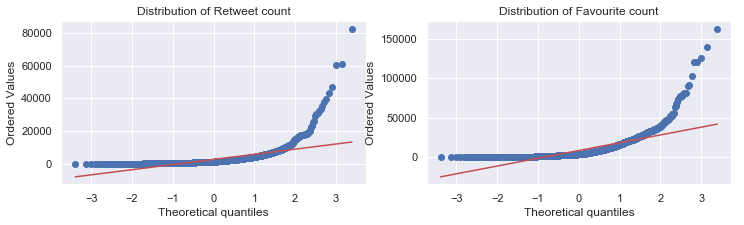

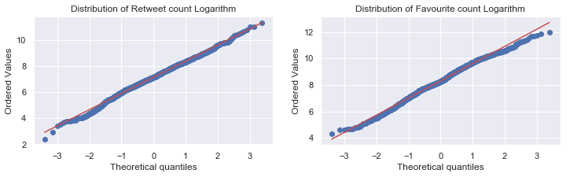

```python
#distribution of retweet and favourite counts
n_rt= df_archive_copy.retweet_count
n_fav= df_archive_copy.favorite_count

fig = plt.figure(figsize=(12,3))

ax1 = fig.add_subplot(121)
stats.probplot(n_rt, plot=plt) #https://docs.scipy.org/doc/scipy/reference/generated/scipy.stats.probplot.html
ax1.set_title("Distribution of Retweet count")

ax2 = fig.add_subplot(122)
stats.probplot(n_fav, plot=plt)
ax2.set_title("Distribution of Favourite count");

#calculate logarithm for non-zero counts
log_rt= np.log(df_archive_copy[df_archive_copy.retweet_count>0].retweet_count)
log_fav= np.log(df_archive_copy[df_archive_copy.favorite_count>0].favorite_count)

fig = plt.figure(figsize=(12,3))

ax3 = fig.add_subplot(121)
stats.probplot(log_rt, plot=plt)
ax3.set_title("Distribution of Retweet count Logarithm")

ax4 = fig.add_subplot(122)
stats.probplot(log_fav, plot=plt);
ax4.set_title("Distribution of Favourite count Logarithm");
```

The counts of favourites and of retweets are approximately log-normally distributed (though retweets, deviate somewhat at very low counts).

### Favourites and retweets are strongly correlated

Seaborn's jointplot function is a good way to look at the relationship between retweet and favourite count

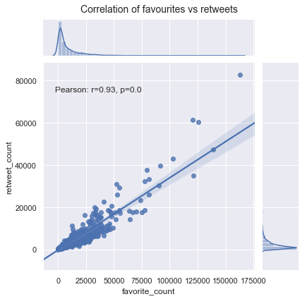

```python
#only consider non-zero values
x=(df_archive_copy[(df_archive_copy.favorite_count>0) & (df_archive_copy.retweet_count>0)].favorite_count)
y=(df_archive_copy[(df_archive_copy.favorite_count>0) & (df_archive_copy.retweet_count>0)].retweet_count)

corr_coeff= stats.pearsonr(x,y) #https://docs.scipy.org/doc/scipy/reference/generated/scipy.stats.pearsonr.html

ax=sns.jointplot(x,y,kind="reg")
ax.fig.text(x=0.3,y=0.7, s="Pearson: r={0:.2f}, p={1:.1f}".format(corr_coeff[0],corr_coeff[1]), ha="center", va="center")
                                    #decimals https://stackoverflow.com/a/8940627
ax.fig.subplots_adjust(top=0.93) #title https://stackoverflow.com/a/29814281
ax.fig.suptitle('Correlation of favourites vs retweets', fontsize=14);
```

Plot the log values of retweet count and of favourite count - to reduce overplotting and get a better distribution of the counts

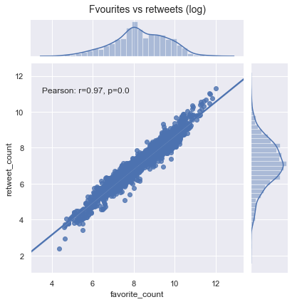

```python
x=np.log(df_archive_copy[(df_archive_copy.favorite_count>0) & (df_archive_copy.retweet_count>0)].favorite_count)
y=np.log(df_archive_copy[(df_archive_copy.favorite_count>0) & (df_archive_copy.retweet_count>0)].retweet_count)

corr_coeff= stats.pearsonr(x,y)

ax=sns.jointplot(x,y,kind="reg")

ax.fig.text(x=0.3,y=0.7, s="Pearson: r={0:.2f}, p={1:.1f}".format(corr_coeff[0],corr_coeff[1]), ha="center", va="center")
ax.fig.subplots_adjust(top=0.93)
ax.fig.suptitle('Fvourites vs retweets (log)', fontsize=14);
```

There is a very stong correlation (r=0.93) between retweet count and favourite count. This can easily be understood as both retweets and favourite are expressions of audience engagement, the former being a stronger form of engagement. There is also a mutual re-inforcement mechanism at play, as tweets that are retweeted are shown to a wider audience, increasing the pool of tweets who may favourite the tweet ; and popular tweets, as expressed by a higher favorite count are given higher prominence in the Twitter timeline. This feedback mechanism is likely to be the basis for the log-normal distribution observed.

### The popularity of WeRateDogs increases steadily over a 20 month period

With nearly 8 million followers, @dog_rates (WeRateDogs) is a very successful Twitter account. How did it get there?

The plot below shows the evolution of audience engagement over the first 20 months. Only original tweets are considered - i.e. replies, quote-tweets and retweets are left out, as audience engagement is fundamentally different with them.

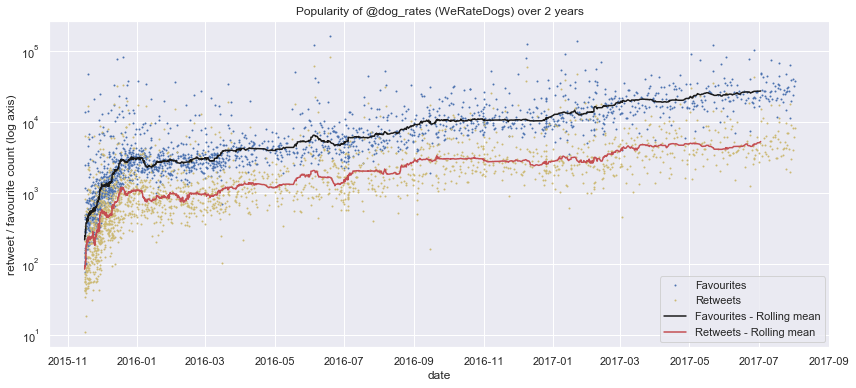

```python
fig, ax = plt.subplots(figsize=(14,6))

x = df_archive_copy[df_archive_copy.tweet_type=='Original'].timestamp

y1 = df_archive_copy[df_archive_copy.tweet_type=='Original'].favorite_count
y1m = y1.rolling(50).median()

y2 = df_archive_copy[df_archive_copy.tweet_type=='Original'].retweet_count
y2m = y2.rolling(50).median()

ax.plot_date(x,y1, color='b', markersize = 1)
ax.plot_date(x,y2, color='y', markersize = 1)

ax.plot(x,y1m, color='k')
ax.plot(x,y2m,color='r')
plt.yscale("log")

ax.set_title("Popularity of @dog_rates (WeRateDogs) over 2 years")
ax.set_ylabel("retweet / favourite count (log axis)")
ax.set_xlabel("date")
ax.legend(['Favourites','Retweets','Favourites - Rolling mean','Retweets - Rolling mean']);
```

During the first month or two, there's a rapid increase in popularity - from tens to thousands of retweets. Thereafter, the slope of the curve become much less steep but increases steadily until the end of the period studied. The approximately linear aspect of the rolling means expresses an exponential increase since the y-axis is logarithmic. The distance between the lines for favourites and retweets is relatively consistent but widens slowly.

WeRateDogs commonly states the name of the dog in the picture, as well as the "dog stage". Does this make the tweets more popular?

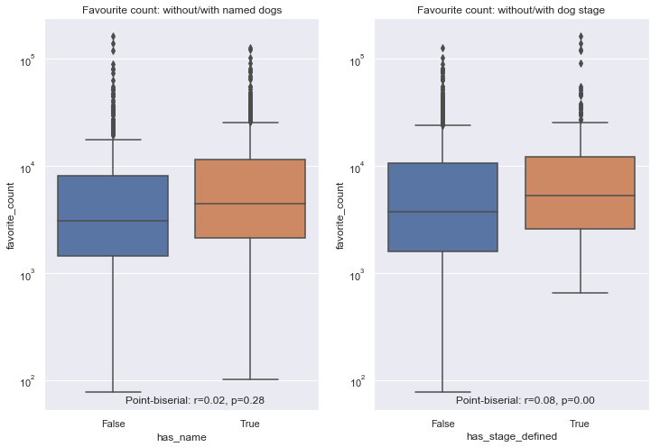

```python
#create new variable stating if name and dog stage are used in text
df_archive_copy['has_name'] = df_archive_copy.name != "None"
df_archive_copy['has_stage_defined']=df_archive_copy.dog_stage != "no stage"

data = df_archive_copy[(df_archive_copy.favorite_count>0) & (df_archive_copy.tweet_type=='Original')]

#correlation https://docs.scipy.org/doc/scipy-0.14.0/reference/generated/scipy.stats.pointbiserialr.html
corr_name = stats.pointbiserialr(data.has_name,data.favorite_count)
corr_stage = stats.pointbiserialr(data.has_stage_defined,data.favorite_count)

fig, (ax1, ax2) = plt.subplots(1,2,figsize=(12,8))
sns.boxplot(y='favorite_count',x='has_name',data= data,ax=ax1).set_title('Favourite count: without/with named dogs')
fig.get_axes()[0].set_yscale('log')

sns.boxplot(y='favorite_count',x='has_stage_defined',data= data,ax=ax2).set_title('Favourite count: without/with dog stage')
fig.get_axes()[1].set_yscale('log')

ax1.text(x=0.6,y=65, s="Point-biserial: r={0:.2f}, p={1:.2f}".format(corr_name[0],corr_name[1]), ha="center", va="center")
ax2.text(x=0.6,y=65, s="Point-biserial: r={0:.2f}, p={1:.2f}".format(corr_stage[0],corr_stage[1]), ha="center", va="center");
```

Is there a discernible effect of retweeting, and of the type of tweet?

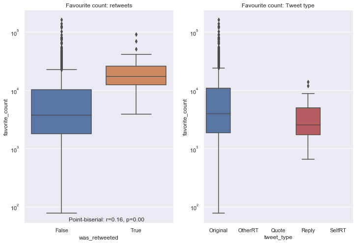

```python
data = df_archive_copy[df_archive_copy.favorite_count>0]

corr_coeff = stats.pointbiserialr(data.was_retweeted,data.favorite_count)

fig, (ax1, ax2) = plt.subplots(1,2,figsize=(12,8))
sns.boxplot(y='favorite_count',x='was_retweeted',data= data,ax=ax1).set_title('Favourite count: retweets')
fig.get_axes()[0].set_yscale('log')
ax1.text(x=0.6,y=60, s="Point-biserial: r={0:.2f}, p={1:.2f}".format(corr_coeff[0],corr_coeff[1]), ha="center", va="center")

sns.boxplot(y='favorite_count',x='tweet_type',data= data,ax=ax2).set_title('Favourite count: Tweet type')
fig.get_axes()[1].set_yscale('log')
```

The box-plot shows that WeRateDogs tweets which are retweeted by the same account have a higher favourite count than those that are not. Thus retweeting is plausibly a good strategy for increasing a tweets popularity.However, the analysis here can't establish causality, because it's certainly possible that popular tweets are more likely to be chosen for retweeting.

### The WeRateDogs ratings system is meaningful

WeRateDogs uses an ideosyncratic rating system for dogs, in which ratings of usually between 10 to 13 out of 10 are used. Lower rating do exist as well as 14, but ratings above 14 are outside of the standard used.

Do these ratings express anything meanful about the dog(s) in question? Below is a regression plot of the rating (numerator) against the dog's popularity (log of favorite count). Only ratings below 15/10 are considered.

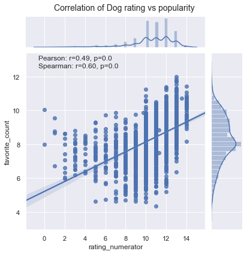

```python
data = df_archive_copy[df_archive_copy.rating_numerator<15]

x = data.rating_numerator
y = np.log(data.favorite_count)

pearson = stats.pearsonr(x,y)
spearman = stats.spearmanr(x,y) #https://docs.scipy.org/doc/scipy-0.14.0/reference/generated/scipy.stats.spearmanr.html

ax=sns.jointplot(x,y,kind="reg")
ax.fig.text(x=0.17,y=0.77, s="Pearson: r={0:.2f}, p={1:.1f}".format(pearson[0],pearson[1]), ha="left", va="center")
ax.fig.text(x=0.17,y=0.74, s="Spearman: r={0:.2f}, p={1:.1f}".format(spearman[0],spearman[1]), ha="left", va="center")

ax.fig.subplots_adjust(top=0.93)
ax.fig.suptitle('Correlation of Dog rating vs popularity', fontsize=14);
```

The plot suggests that the rating system is meaningful and there is in fact a relationship between the rating and the popularity of a dog. The Pearson correlation coefficient of r=0.49 is lower than the Spearman correlation coefficient r=0.60, since Pearson only measure linear relationships. Again, it is not possible to draw any conclusions re. causality here - it may be that a higher rating biases the audience to favour a dog picture, or it may be that a high/low favourite count and a high/low dog rating are both independently caused by how great a dog picture is.

Are young dogs more popular? Are certain breeds more popular? The box plot below looks at this question.

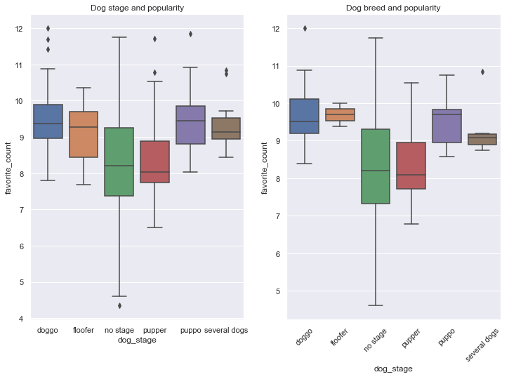

```python
fig, (ax1, ax2) = plt.subplots(1,2,figsize=(12,8))

x= df_archive_copy.dog_stage
y= np.log(df_archive_copy.favorite_count)
sns.boxplot(x,y,data = df_archive_copy,ax=ax1).set_title('Dog stage and popularity')

top_dogs=df_archive_copy.top_prediction.value_counts().head(8).index.tolist()

data=df_archive_copy[df_archive_copy.top_prediction.isin(top_dogs)]
x= data.dog_stage
y= np.log(data.favorite_count)

sns.boxplot(x,y,data = data,ax=ax2).set_title('Dog breed and popularity')
plt.xticks(rotation=45);
```

The most popular dog stages are "puppo", "doggo" and "floofer", whose median popularity is about one unit above that of "pupper" and photos of dogs where no 'dog stage' is mentioned. It is perhaps surprising that "pupper" has the lowest median popularity rating - this suggests that it isn't simply the fact that a dog staage is mentioned in a tweet that contributes to its popularity.

### The most common breed is Golden Retriever

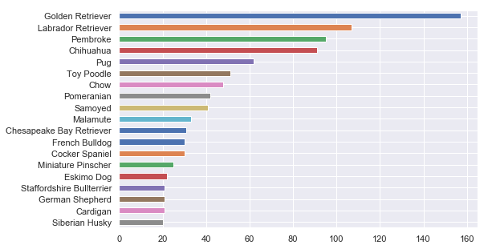

```python
df_archive_copy.top_prediction.value_counts()[1:20].plot.barh(figsize=(8,5))
plt.gca().invert_yaxis()
```

### The most common dog names Cooper, Lucy, Charlie and Oliver

Similarly, our cleaned data enable us to find out what the most common dog names are.

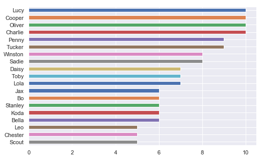

```python
df_archive_copy.name.value_counts()[1:20].plot.barh(figsize=(8,5))
plt.gca().invert_yaxis();
```

**Sources used**

A number of sources were used for this project - links are usually made available as comments

- https://seaborn.pydata.org/tutorial/regression.html
- https://seaborn.pydata.org/generated/seaborn.catplot.html
- https://developer.twitter.com/en/docs/basics/twitter-ids.html
- https://developer.twitter.com/en/docs/tweets/data-dictionary/overview/intro-to-tweet-json.html
- https://docs.scipy.org/doc/scipy-0.14.0/reference/generated/scipy.stats.pointbiserialr.html
- https://docs.scipy.org/doc/scipy-0.14.0/reference/generated/scipy.stats.spearmanr.html
- https://docs.scipy.org/doc/scipy/reference/generated/scipy.stats.pearsonr.html
- https://docs.scipy.org/doc/scipy/reference/generated/scipy.stats.probplot.html
- https://pandas.pydata.org/pandas-docs/version/0.24/whatsnew/v0.24.0.html#optional-integer-na-support
- https://stackoverflow.com/a/11548224
- https://stackoverflow.com/a/18117744
- https://stackoverflow.com/a/18937252
- https://stackoverflow.com/a/19960116
- https://stackoverflow.com/a/27901076
- https://stackoverflow.com/a/29814281
- https://stackoverflow.com/a/44586034
- https://stackoverflow.com/a/49469052
- https://stackoverflow.com/a/8940627